# Can We Utilize Diet, Age, and Other Health Metrics to Effectively Model Blood Pressure Measurements & Associated Diagnoses?

# R Packages and Setup

```r
library(knitr)
library(rmdformats)
library(janitor)
library(magrittr)
library(naniar)
library(broom)
library(patchwork)
library(nhanesA)
library(measurements)
library(readxl)
library(Epi)
library(Hmisc)
library(simputation)
library(rms)
library(pander)
library(GGally)
library(car)
library(mice)
library(ROCR)
library(caret)
library(tidyverse)

theme_set(theme_bw())
```

# 1 Data Source

The data for this project was acquired from the *National Health and Nutrition Examination Survey* (i.e. NHANES), specifically from their [2017-2018 data files](https://wwwn.cdc.gov/nchs/nhanes/continuousnhanes/default.aspx?BeginYear=2017), as this was the last year that the National Center for Health Statistics was able to finish without interference from the pandemic. The National Center for Health Statistics, as a [division of the CDC](https://www.cdc.gov/nchs/about/organization.htm), collects this data to assess the health and nutritional status of adults and children in the United States, and has been continuously collecting and publishing this data for public use every 2 years since 1999. According to the CDC’s [National Health and Nutrition Examination Survey: Plan and Operations, 1999-2010 documentation](https://www.cdc.gov/nchs/data/series/sr_01/sr01_056.pdf), the 2-year cycle for collecting and publishing data was chosen to ensure the stability/accuracy of these measurements, as well as to mitigate the possibility of unintentional disclosure of a sample person’s identity. Additionally, the documentation states the general sample design methodology used to determine the selection of subjects for this survey, however some alterations were made to these methods for the 2015-2018 cycles, as is detailed in the CDC’s [National Health and Nutrition Examination Survey, 2015-2018: Sample Design and Estimation Procedures documentation](https://www.cdc.gov/nchs/data/series/sr_02/sr02-184-508.pdf). The documentation states that the general sample design for their data collection was not simple random sampling, but complex, multistage probability sampling, utilized to develop a representative sample of the United States’ civilian non-institutionalized household population. Briefly, this involved four steps:

- First, selecting for primary sampling units, which consisted of either counties or small groups of contiguous counties
- Then selecting segments within these areas that contain a cluster of households
- Then selecting for specific households within the segments chosen above
- Lastly then selecting for individuals within each household for sampling

For the 2015-2018 cycles, this same methodology was used, however some sub-groups were over-sampled to increase the precision of the associated sub-group estimates. These sub-groups are as follows:

- Hispanic persons
- Non-Hispanic black persons
- Non-Hispanic, non-black Asian persons
- Non-Hispanic white persons and persons of other races and ethnicities at or below 185% of the federal poverty level
- Non-Hispanic white persons and persons of other races and ethnicities aged 0–11 years or 80 years and over

# 2 The Subjects

The subjects in my analyses will be individuals selected from the 2017-2018 NHANES datasets as discussed above, where each row represents one participant. The goal will be to generate models to examine two different outcomes - the systolic blood pressure of the participants as measured with an oscillometric device (quantitative outcome), and whether or not they have been diagnosed with high blood pressure by their doctor (binary outcome) - by using the participant’s sodium levels (mmol/L), potassium levels (mmol/L), insomnia diagnosis, and milk consumption type as the predictors.

# 3 Loading and Tidying the Data

This section will involve downloading the necessary data files from the respective sources for use in this project, and will process these files as necessary to prepare them for use in creating the analysis dataset.

## 3.1 Loading the Raw Data

The code below utilizes the `nhanesA` library to download the necessary data files from the NHANES databases by loading them into RStudio as tibbles, saving them as .Rds files so they do not need to be downloaded again, and then redefining the variables currently assigned to load the files from the website to load the local copies back instead to use to create the analysis dataset:

```r
DEMO_J_raw <- nhanes('DEMO_J') %>% tibble()
```

```
Processing SAS dataset DEMO_J    ..
```

```r
BPXO_J_raw <- nhanes('BPXO_J') %>% tibble()
```

```
Processing SAS dataset BPXO_J    ..
```

```r
BPQ_J_raw <- nhanes('BPQ_J') %>% tibble()
```

```
Processing SAS dataset BPQ_J     ..
```

```r
BIOPRO_J_raw <- nhanes('BIOPRO_J') %>% tibble()
```

```
Processing SAS dataset BIOPRO_J      ..
```

```r
DBQ_J_raw <- nhanes('DBQ_J') %>% tibble()
```

```
Processing SAS dataset DBQ_J     ..
```

```r
SLQ_J_raw <- nhanes('SLQ_J') %>% tibble()
```

```
Processing SAS dataset SLQ_J     ..
```

```r
saveRDS(DEMO_J_raw, "data/DEMO_J.Rds")
saveRDS(BPXO_J_raw, "data/BPXO_J.Rds")
saveRDS(BPQ_J_raw, "data/BPQ_J.Rds")
saveRDS(BIOPRO_J_raw, "data/BIOPRO_J.Rds")
saveRDS(DBQ_J_raw, "data/DBQ_J.Rds")
saveRDS(SLQ_J_raw, "data/SLQ_J.Rds")

DEMO_J_raw <- readRDS("data/DEMO_J.Rds")
BPXO_J_raw <- readRDS("data/BPXO_J.Rds")
BPQ_J_raw <- readRDS("data/BPQ_J.Rds")
BIOPRO_J_raw <- readRDS("data/BIOPRO_J.Rds")
DBQ_J_raw <- readRDS("data/DBQ_J.Rds")
SLQ_J_raw <- readRDS("data/SLQ_J.Rds")
```

## 3.2 Cleaning the Data

The predictors and outcome variables will be clearly defined in the **Defining the Variables** sub-section of **The Code Book** section below, but before that the raw data files need to be processed and ultimately combined into an aggregated tibble for use in each analysis. This will be accomplished in steps in the following section.

### 3.2.1 Selecting and Filtering for the Relevant Data

The first step of the data cleaning process will be to select for and filter each of the raw data files for just the variables needed, and also filter out any unwanted results from the variables where appropriate. This is accomplished with the following code, and while again each variable will be clarified in **The Code Book** section, it’s worth noting the following about the keys from the NHANES website at this point to understand the code below:

- 7 represents instances where the respondent refused to respond to the question
- 9 represents instances where the respondent reported that they didn’t know the answer to the question

Additionally, it’s worth noting the following about the demographics data selection from the `DEMO_J` data shown below:

- `RIDAGEYR` represents the respondent’s age, and for the following analyses we will only be interested in respondents that are between the ages of 18 and 79, as ages past 79 are all recorded as 80, and while we could include children in this study, we will omit them and focus the study on adults of 18 or older.

The code for selecting and filtering the data is as follows:

```r
DEMO_J_data = DEMO_J_raw %>%
  select(c(SEQN, RIDAGEYR)) %>%
  filter(RIDAGEYR <= 79) %>%
  filter(RIDAGEYR >= 18)

BPXO_J_data = BPXO_J_raw %>%
  select(c(SEQN, BPXOSY3))

BPQ_J_data = BPQ_J_raw %>%
  select(c(SEQN, BPQ020)) %>%
  filter(BPQ020 != 7) %>%
  filter(BPQ020 != 9)

SLQ_J_data = SLQ_J_raw %>%
  select(c(SEQN, SLQ050)) %>%
  filter(SLQ050 != 7) %>%
  filter(SLQ050 != 9)

BIOPRO_J_data = BIOPRO_J_raw %>%
  select(c(SEQN, LBXSNASI, LBXSKSI))
```

It’s worth noting that the code above selects and filters for all but 1 variable that will be used in this analysis. This last variable will require a more complex approach than the above, so it will be addressed in its own sub-section after the rest of the variables above have been addressed. For now, we can proceed to the next step in preparing the above data.

### 3.2.2 Renaming & Formatting the Data

The next logical step for preparing the data is to properly format each variable, and provide each with a more appropriate name, both of which are accomplished below with the following code:

```r
DEMO_J_data = DEMO_J_data %>%
  mutate(SEQN = as.numeric(SEQN)) %>%
  mutate(RIDAGEYR = as.numeric(RIDAGEYR)) %>%
  rename(Age = RIDAGEYR)

BPXO_J_data = BPXO_J_data %>%
  mutate(SEQN = as.numeric(SEQN)) %>%
  mutate(BPXOSY3 = as.numeric(BPXOSY3)) %>%
  rename("Systolic_BP" = BPXOSY3)

BPQ_J_data = BPQ_J_data %>%
  mutate(SEQN = as.numeric(SEQN)) %>%
  mutate(BPQ020 = fct_recode(as.factor(BPQ020),
                             "Yes" = "1",
                             "No" = "2")) %>%
  mutate(BPQ020 = fct_relevel(BPQ020, "No", "Yes")) %>%
  rename("High_BP" = BPQ020)

SLQ_J_data = SLQ_J_data %>%
  mutate(SEQN = as.numeric(SEQN)) %>%
  mutate(SLQ050 = fct_recode(as.factor(SLQ050),
                             "Yes" = "1",
                             "No" = "2")) %>%
  mutate(SLQ050 = fct_relevel(SLQ050, "No", "Yes")) %>%
  rename("Insomnia" = SLQ050)

BIOPRO_J_data = BIOPRO_J_data %>%
  mutate(SEQN = as.numeric(SEQN)) %>%
  mutate(LBXSNASI = as.numeric(LBXSNASI)) %>%
  mutate(LBXSKSI = as.numeric(LBXSKSI)) %>%
  rename(Sodium = LBXSNASI) %>%
  rename(Potassium = LBXSKSI)
```

With the code above, all but two of the variables have been properly extracted and reformatted. The only variables that has not been addressed yet are the `SEQN` variable, which is the subject ID variable, and another variable from the `DBQ_J` data file, which will become the `Milk` multi-categorical variable. Both of these have been set aside intentionally, as it will be more efficient to rename the `SEQN` variable in the analysis tibble itself after it is generated, instead of altering each instance of it in each of the individual data files above, and the `Milk` variable is complicated enough to warrant its own sub-section, which will be addressed next.

### 3.2.3 The Milk Variable

As mentioned above, all of the variables have been addressed above, with only two exceptions - the subject ID variable `SEQN`, which will be renamed once the tibble is generated, and the Milk variable, which will be addressed in this section. The intent is to use this variable as an additional multi-categorical variable for both analyses, however preparing it for such use will require additional and more sophisticated steps because of the manner in which it was recorded in the NHANES dataset. In particular, the survey participants were asked two questions:

- How often did they drink milk in the past 30 day period?
- If they did drink any milk, what type of milk did they mainly drink?

While the former question’s results were recorded as a single, multi-categorical variable, the results to the latter, which is what we are interested in, were stored in 6 unique variables, depending on their answer - Whole Milk, 2% Milk, 1% Milk, Skim Milk, Soy Milk, or Other Milk. Additionally, if the participant was uncertain of which milk they mainly drink, the survey recorder was to record all of the milk types that the participant reported that they drank. This means that to prepare this variable for use in the later analyses, the results from all 6 answer variables need to be collapsed into one multi-categorical field that both keeps the NA values for later imputation, but also removes participants that were uncertain as to which milk they mainly drank and as such reported multiple milk types, as there would be no clear way to classify the latter results into any of the other pre-defined fields. To accomplish this, the first step was taken with the code below, which extracts the variables from the raw data file and stores the positive values and NA values in separate data frames:

```r
DBQ_J_data1 = DBQ_J_raw %>%
  select(c(SEQN, DBQ223A)) %>%
  filter(DBQ223A == 10) %>%
  mutate(DBQ223A = as.numeric(DBQ223A))

DBQ_J_data2 = DBQ_J_raw %>%
  select(c(SEQN, DBQ223B)) %>%
  filter(DBQ223B == 11) %>%
  mutate(DBQ223B = as.numeric(DBQ223B))

DBQ_J_data3 = DBQ_J_raw %>%
  select(c(SEQN, DBQ223C)) %>%
  filter(DBQ223C == 12) %>%
  mutate(DBQ223C = as.numeric(DBQ223C))

DBQ_J_data4 = DBQ_J_raw %>%
  select(c(SEQN, DBQ223D)) %>%
  filter(DBQ223D == 13) %>%
  mutate(DBQ223D = as.numeric(DBQ223D))

DBQ_J_data5 = DBQ_J_raw %>%
  select(c(SEQN, DBQ223E)) %>%
  filter(DBQ223E == 14) %>%
  mutate(DBQ223E = as.numeric(DBQ223E))

DBQ_J_data6 = DBQ_J_raw %>%
  select(c(SEQN, DBQ223U)) %>%
  filter(DBQ223U == 30) %>%
  mutate(DBQ223U = as.numeric(DBQ223U))


DBQ_J_data1_NA = DBQ_J_raw %>%
  select(c(SEQN, DBQ223A)) %>%
  filter(is.na(DBQ223A)) %>%
  rename(DBQ223 = DBQ223A) %>%
  mutate(DBQ223 = as.numeric(DBQ223))

DBQ_J_data2_NA = DBQ_J_raw %>%
  select(c(SEQN, DBQ223B)) %>%
  filter(is.na(DBQ223B)) %>%
  rename(DBQ223 = DBQ223B) %>%
  mutate(DBQ223 = as.numeric(DBQ223))

DBQ_J_data3_NA = DBQ_J_raw %>%
  select(c(SEQN, DBQ223C)) %>%
  filter(is.na(DBQ223C)) %>%
  rename(DBQ223 = DBQ223C) %>%
  mutate(DBQ223 = as.numeric(DBQ223))

DBQ_J_data4_NA = DBQ_J_raw %>%
  select(c(SEQN, DBQ223D)) %>%
  filter(is.na(DBQ223D)) %>%
  rename(DBQ223 = DBQ223D) %>%
  mutate(DBQ223 = as.numeric(DBQ223))

DBQ_J_data5_NA = DBQ_J_raw %>%
  select(c(SEQN, DBQ223E)) %>%
  filter(is.na(DBQ223E)) %>%
  rename(DBQ223 = DBQ223E) %>%
  mutate(DBQ223 = as.numeric(DBQ223))

DBQ_J_data6_NA = DBQ_J_raw %>%
  select(c(SEQN, DBQ223U)) %>%
  filter(is.na(DBQ223U)) %>%
  rename(DBQ223 = DBQ223U) %>%
  mutate(DBQ223 = as.numeric(DBQ223))
```

Now that the variables have been properly extracted from the raw files, the milk results and NA results for each milk type can be combined to form two files - one for people who responded with at least one milk type, and one where the participant did not answer with any milk type, which will be the missing values for this variable. The former will be generated using `full_join` to preserve all responses, and the latter will be generated using `inner_join` to filter only for missing responses present in all 6 variables, effectively filtering only for participants with missing data:

```r
DBQ_J_data_milk = full_join(
  full_join(
    full_join(
      full_join(
        full_join(DBQ_J_data1,
                  DBQ_J_data2,
                  by = c("SEQN")),
        DBQ_J_data3,
        by = c("SEQN")),
      DBQ_J_data4,
      by = c("SEQN")),
    DBQ_J_data5,
    by = c("SEQN")),
  DBQ_J_data6,
  by = c("SEQN"))

DBQ_J_data_NA = inner_join(
  inner_join(
    inner_join(
      inner_join(
        inner_join(DBQ_J_data1_NA,
                   DBQ_J_data2_NA,
                   by = c("SEQN", "DBQ223")),
        DBQ_J_data3_NA,
        by = c("SEQN", "DBQ223")),
      DBQ_J_data4_NA,
      by = c("SEQN", "DBQ223")),
    DBQ_J_data5_NA,
    by = c("SEQN", "DBQ223")),
  DBQ_J_data6_NA,
  by = c("SEQN", "DBQ223"))
```

Before the two resulting tables above can be combined, the results in `DBQ_J_data_milk` need to be further processed to collapse all of the results down into one column in a manner that also creates a means for removing any participants that answered with multiple milk types. This will be accomplished by creating a new field that sums all of the fields together per row - as each answer was given a unique numeric identifier in the survey data, and since no combination(s) of these numbers when summed equal each other, summing their responses is one method that can be used to determine whether or not a participant answered with multiple milk types without affecting those that only provided a single answer. As such, the code below generates this new column to this end, filtering out any unsuitable participants, and after doing so formats and renames the column as appropriate:

```r
DBQ_J_data_milk = DBQ_J_data_milk %>%
  mutate(DBQ223 = rowSums(across(DBQ223A:DBQ223U), na.rm = TRUE)) %>%
  select(c(SEQN, DBQ223)) %>%
  filter(DBQ223 == 10 |
           DBQ223 == 11 |
           DBQ223 == 12 |
           DBQ223 == 13 |
           DBQ223 == 14 |
           DBQ223 == 30)
```

Now that the responses have been properly filtered for participants who only answered with one milk type, the `DBQ_J_data_milk` and `DBQ_J_data_NA` files can be joined together using `full_join` as shown below:

```r
DBQ_J_data = full_join(DBQ_J_data_milk, DBQ_J_data_NA, by = c("SEQN", "DBQ223"))
```

As the last step, the milk type variable will be reformatted as a factor variable, with appropriate names given to each factor level, and will be renamed more appropriately using the code below:

```r
DBQ_J_data = DBQ_J_data %>%
  mutate(SEQN = as.numeric(SEQN)) %>%
  mutate(DBQ223 = fct_recode(as.factor(DBQ223),
                                  "Whole Milk" = "10",
                                  "2% Milk" = "11",
                                  "1% Milk" = "12",
                                  "Skim Milk" = "13",
                                  "Soy Milk" = "14",
                                  "Other Milk" = "30")) %>%
  rename(Milk = DBQ223)
```

With all of the above finally out of the way, all of the necessary preparation steps have been taken for each variable, and the data can be pulled together to form the analysis tibble, which will be accomplished in the last sub-section below.

## 3.3 Creating the Tibble

Now that the data for all of the variables have been properly selected and formatted, the files can be pulled together to create the analysis tibble, reorder the variables for more logical discussion in **The Code Book** section, and the subject ID variable `SEQN` can be renamed to something more suitable, all of which have been accomplished with the code below:

```r
analysis_data_raw = inner_join(inner_join(inner_join(inner_join(inner_join(DEMO_J_data, BPXO_J_data, by = c("SEQN")), BPQ_J_data, by = c("SEQN")), SLQ_J_data, by = c("SEQN")), BIOPRO_J_data, by = c("SEQN")), DBQ_J_data, by = c("SEQN")) %>%
  rename(Subject_ID = SEQN)

col_order = c("Subject_ID", "Systolic_BP", "High_BP", "Age", "Sodium", "Potassium", "Insomnia", "Milk")

analysis_data_raw = analysis_data_raw[, col_order]
```

Now that the analysis dataset has been generated, we need to make sure that it fits the necessary criteria for this project. First of all, the dataset needs to have no more than 1200 subjects, so lets check how many it has:

```r
count(analysis_data_raw)
```

```
# A tibble: 1 x 1
      n
  <int>
1  4955
```

It clearly has more than 1200 samples, currently having 4955 currently. As such we’ll use the following code to create a sub-set of this dataset for this project using the following code:

```r
set.seed(43202)

analysis_data = analysis_data_raw %>%
  slice_sample(n = 1200)
```

For confirmation that this worked as intended, let’s check the subject count again:

```r
count(analysis_data)
```

```
# A tibble: 1 x 1
      n
  <int>
1  1200
```

Looks good - now let’s check each of the categorical predictor/input variables - `Milk` and `Insomnia` - and the outcome variable, `High_BP`, to ensure that they all have a minimum of 30 values in each category:

```r
analysis_data %>% count(Milk)
```

```
# A tibble: 7 x 2
  Milk           n
  <fct>      <int>
1 Whole Milk   328
2 2% Milk      349
3 1% Milk       84
4 Skim Milk     42
5 Soy Milk      30
6 Other Milk    87
7 <NA>         280
```

```r
analysis_data %>% count(Insomnia)
```

```
# A tibble: 2 x 2
  Insomnia     n
  <fct>    <int>
1 No         872
2 Yes        328
```

```r
analysis_data %>% count(High_BP)
```

```
# A tibble: 2 x 2
  High_BP     n
  <fct>   <int>
1 No        767
2 Yes       433
```

The **Soy Milk** category in the `Milk` variable just barely passes, having exactly 30 instances, however it is unwise to use a categorical variable with so few instances, so to rectify this the `1% Milk` and `Skim Milk` categories will be collapsed together to form a single category. Additionally, since the counts are rather low for the `Soy Milk` and `Other Milk` categories, these two categories will be collapsed together as well, which will create a 4-level categorical variable instead:

```r
analysis_data = analysis_data %>%
  mutate(Milk = fct_recode(as.factor(Milk),
         "1% or Skim Milk" = "1% Milk",
         "1% or Skim Milk" = "Skim Milk",
         "Soy or Other Milk" = "Soy Milk",
         "Soy or Other Milk" = "Other Milk"))

analysis_data %>% count(Milk)
```

```
# A tibble: 5 x 2
  Milk                  n
  <fct>             <int>
1 Whole Milk          328
2 2% Milk             349
3 1% or Skim Milk     126
4 Soy or Other Milk   117
5 <NA>                280
```

For the last check, let’s check each of the quantitative variables - `Age`, `Sodium`, and `Potassium` - and the outcome variable, `Systolic_BP`, to ensure that they all have a minimum of 10 different, ordered, observed values:

```r
analysis_data %$% n_distinct(Age)
```

```
[1] 62
```

```r
analysis_data %$% n_distinct(Sodium)
```

```
[1] 20
```

```r
analysis_data %$% n_distinct(Potassium)
```

```
[1] 29
```

```r
analysis_data %$% n_distinct(Systolic_BP)
```

```
[1] 92
```

The variable with the lowest number of distinct values, `Sodium`, has 20 distinct values, so the data meets the this criteria, and should be suitable for the following analyses.

# 4 The Tidy Tibble

## 4.1 Listing the Tibble

The following code lists the first 10 rows of the tibble:

```r
analysis_data
```

```
# A tibble: 1,200 x 8
   Subject_ID Systolic_BP High_BP   Age Sodium Potassium Insomnia Milk
        <dbl>       <dbl> <fct>   <dbl>  <dbl>     <dbl> <fct>    <fct>
 1      95380         122 No         62    138       4.3 No       Soy or Other ~
 2      98905          NA Yes        63    137       4.5 Yes      <NA>
 3      99128         105 No         36    143       3.9 No       2% Milk
 4      94105         107 No         46    144       4.1 No       2% Milk
 5     101756         110 Yes        61    140       3.6 No       Whole Milk
 6      97319         123 Yes        32    139       4.1 No       Whole Milk
 7     101001         145 No         67    144       4.4 No       Soy or Other ~
 8      95330         124 Yes        77    137       3.9 Yes      Soy or Other ~
 9      94525          NA Yes        66    141       4   No       2% Milk
10     101336         147 No         72    145       4.3 No       2% Milk
# ... with 1,190 more rows
```

## 4.2 Size and Identifiers

### 4.2.1 Size

The size of the `analysis_data` dataset was technically already established in the previous sub-section above, as the generated tibble states that the dataset has 1200 rows (as we reduced it to for this analysis) and 8 columns. This can be verified again through the use of the `nrow` and `ncol` functions as shown below:

```r
nrow(analysis_data)
```

```
[1] 1200
```

```r
ncol(analysis_data)
```

```
[1] 8
```

With this verified, we can proceed to the next step of verifying the unique row identifiers in the next sub-section.

### 4.2.2 Identifiers

As already mentioned during the data preparation phase, the `Subject ID` variable (formally the `SEQN` variable) represents each subject’s unique ID, and as such can be used to uniquely identify each entry in the `analysis_data` dataset. This is illustrated with the use of the following code below:

```r
analysis_data %$% n_distinct(Subject_ID)
```

```
[1] 1200
```

## 4.3 Saving the R data set

The following code will save the `analysis_data` tibble as an .Rds file:

```r
saveRDS(analysis_data, "data/analysis_data.Rds")
```

# 5 The Code Book

## 5.1 Defining the Variables

| Variable | Role | Type | Description |
| --- | --- | --- | --- |
| `Subject_ID` | Identifier | - | The unique numeric code assigned to each NHANES respondent/subject/participant. |
| `Systolic_BP` | Outcome/Input | Quantitative | Respondent’s/Subject’s/Participant’s 3rd reading for their Systolic Blood Pressure, in mm Hg, as measured with an oscillometric device. |
| `High_BP` | Outcome/Input | 2-Categorical | Has the respondent/subject/participant been diagnosed with high blood pressure by their doctor? (Yes or No) |
| `Age` | Input | Quantitative | What was the age of the respondent/subject/participant at the time the data was collected? |
| `Sodium` | Input | Quantitative | Respondent’s/Subject’s/Participant’s sodium level in mmol/L, as indicated by their blood test. |
| `Potassium` | Input | Quantitative | Respondent’s/Subject’s/Participant’s potassium level in mmol/L, as indicated by their blood test. |
| `Insomnia` | Input | 2-Categorical | Has the respondent/subject/participant disclosed that they have been having trouble sleeping to their doctor? (Yes or No) |
| `Milk` | Input | 4-Categorical | What type of milk does the respondent/subject/participant mainly drink? (Whole Milk, 2% Milk, 1% or Skim Milk, Soy or Other Milk) |

## 5.2 Numerical Description

The following code provides a numerical description of the `analysis_data` dataset through the use of the `describe` function from the `Hmisc` package:

```r
describe(analysis_data)
```

```
analysis_data

 8  Variables      1200  Observations
--------------------------------------------------------------------------------
Subject_ID
       n  missing distinct     Info     Mean      Gmd      .05      .10
    1200        0     1200        1    98273     3137    94094    94562
     .25      .50      .75      .90      .95
   95867    98208   100620   102033   102616

lowest :  93708  93709  93714  93718  93721, highest: 102907 102908 102947 102949 102956
--------------------------------------------------------------------------------
Systolic_BP
       n  missing distinct     Info     Mean      Gmd      .05      .10
    1049      151       91        1    123.2    20.42       97      101
     .25      .50      .75      .90      .95
     110      121      134      148      157

lowest :  73  88  89  90  91, highest: 176 177 184 185 187
--------------------------------------------------------------------------------
High_BP
       n  missing distinct
    1200        0        2

Value         No   Yes
Frequency    767   433
Proportion 0.639 0.361
--------------------------------------------------------------------------------
Age
       n  missing distinct     Info     Mean      Gmd      .05      .10
    1200        0       62        1       48    20.17       20       23
     .25      .50      .75      .90      .95
      33       50       62       70       74

lowest : 18 19 20 21 22, highest: 75 76 77 78 79
--------------------------------------------------------------------------------
Sodium
       n  missing distinct     Info     Mean      Gmd      .05      .10
    1121       79       19    0.987    140.3    3.047      136      137
     .25      .50      .75      .90      .95
```

[output cut: 25 more lines]

```
Frequency    872   328
Proportion 0.727 0.273
--------------------------------------------------------------------------------
Milk
       n  missing distinct
     920      280        4

Value             Whole Milk           2% Milk   1% or Skim Milk
Frequency                328               349               126
Proportion             0.357             0.379             0.137

Value      Soy or Other Milk
Frequency                117
Proportion             0.127
--------------------------------------------------------------------------------
```

# 6 Linear Regression Plans

With my linear model as detailed below, I hope to answer the following question:

- Can an adult’s current systolic blood pressure be effectively predicted as a function of their sodium levels, potassium levels, age, milk consumption type, whether they have a past high blood pressure diagnosis, and their insomnia disclosure?

## 6.1 My Quantitative Outcome

While this was briefly broached in **The Subjects** section above, the quantitative outcome that will be used for the linear regression model in this project is the 3rd systolic blood pressure measurement as taken with an oscillometric device, which is listed as `Systolic_BP` in **The Code Book** section above. The 3rd measurement taken with an oscillometric device was specifically chosen in an effort to use the most accurate “at rest” systolic blood pressure as possible. In order to assess this outcome graphically without imputing data, we’ll need to filter out any missing data, which consequently will allow us to provide a count of rows with complete data on this outcome. The code necessary to create a new dataset that has been filtered for complete data only, for `Systolic_BP` in particular, and provides the count for the number of rows (i.e. subjects) with complete data on this metric is as follows:

```r
demo_data = analysis_data %>%
  filter(Systolic_BP != ".")

nrow(demo_data)
```

```
[1] 1049
```

As can be seen above, there are 1049 rows with complete data on this outcome - using just the complete data, we can create the following Normal Q-Q plot, Histogram with an overlaying Density Plot, and Violin Box-plot to assess the distribution of this outcome:

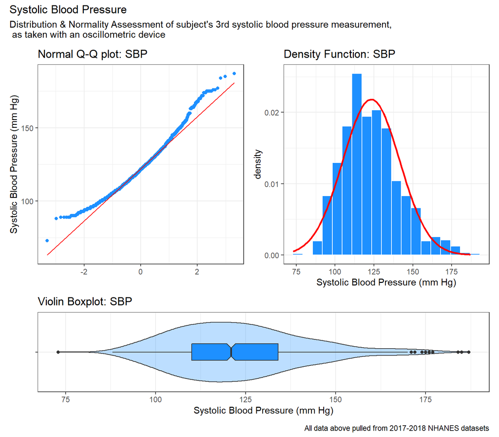

```r
a1 <- ggplot(demo_data, aes(x = "", y = Systolic_BP)) +
  geom_violin(fill = "dodgerblue", alpha = 0.3) +
  geom_boxplot(width = 0.25, fill = "dodgerblue", notch = TRUE) +
  coord_flip() +
  labs(title = "Violin Boxplot: SBP", x = "", y = "Systolic Blood Pressure (mm Hg)")

a2 <- ggplot(demo_data, aes(x = Systolic_BP)) +
  geom_histogram(aes(y = stat(density)), bins = nclass.scott(demo_data$Systolic_BP), col = "white", fill = "dodgerblue") +
  stat_function(fun = dnorm, args = list(mean = mean(demo_data$Systolic_BP), sd = sd(demo_data$Systolic_BP)), col = "red", lwd = 1) +
  labs(title = "Density Function: SBP", x = "Systolic Blood Pressure (mm Hg)")

a3 <- ggplot(demo_data, aes(sample = Systolic_BP)) +
  geom_qq(col = "dodgerblue") +
  geom_qq_line(col = "red") +
  labs(title = "Normal Q-Q plot: SBP", x = "", y = "Systolic Blood Pressure (mm Hg)")

(a3 + a2) / a1 +
  plot_layout(heights = c(5,2)) +
  plot_annotation(title = "Systolic Blood Pressure",
                  subtitle = "Distribution & Normality Assessment of subject's 3rd systolic blood pressure measurement,\n as taken with an oscillometric device",
                  caption = "All data above pulled from 2017-2018 NHANES datasets")
```

Additionally, while this was already demonstrated in the **Creating the Tibble** sub-section of the **Loading and Tidying** section above, this outcome variable has a least 10 different, ordered, observed values, specifically having 92, which can once again be seen with the following code:

```r
analysis_data %$% n_distinct(Systolic_BP)
```

```
[1] 92
```

This code produces a tibble showing all of the unique values, counting how many times each one occurs:

```r
analysis_data %>% count(Systolic_BP)
```

```
# A tibble: 92 x 2
   Systolic_BP     n
         <dbl> <int>
 1          73     1
 2          88     1
 3          89     5
 4          90     5
 5          91     2
 6          92     4
 7          93     6
 8          94     7
 9          95     9
10          96    10
# ... with 82 more rows
```

## 6.2 My Planned Predictors (Linear Model)

```r
analysis_data %$% n_distinct(Age)
```

```
[1] 62
```

```r
analysis_data %$% n_distinct(Sodium)
```

```
[1] 20
```

```r
analysis_data %$% n_distinct(Potassium)
```

```
[1] 29
```

As with the outcome variable `Systolic_BP` shown above, the following code produces a tibble for each, each showing all of the unique values and counting how many times each one occurs:

```r
analysis_data %>% count(Age)
```

```
# A tibble: 62 x 2
     Age     n
   <dbl> <int>
 1    18    32
 2    19    26
 3    20    17
 4    21    16
 5    22    20
 6    23    24
 7    24    17
 8    25    16
 9    26    24
10    27    15
# ... with 52 more rows
```

```r
analysis_data %>% count(Sodium)
```

```
# A tibble: 20 x 2
   Sodium     n
    <dbl> <int>
 1    128     2
 2    130     1
 3    132     1
 4    133     3
 5    134     7
 6    135    28
 7    136    47
 8    137    68
 9    138   134
10    139   126
11    140   174
12    141   159
13    142   137
14    143    95
15    144    75
16    145    33
17    146    20
18    147    10
19    148     1
20     NA    79
```

```r
analysis_data %>% count(Potassium)
```

```
# A tibble: 29 x 2
   Potassium     n
       <dbl> <int>
 1       2.9     2
 2       3       3
 3       3.1     2
 4       3.2     3
 5       3.3     9
 6       3.4    19
 7       3.5    30
 8       3.6    45
 9       3.7    72
10       3.8   102
# ... with 19 more rows
```

```r
analysis_data %>% count(Milk)
```

```
# A tibble: 5 x 2
  Milk                  n
  <fct>             <int>
1 Whole Milk          328
2 2% Milk             349
3 1% or Skim Milk     126
4 Soy or Other Milk   117
5 <NA>                280
```

```r
analysis_data %>% count(Insomnia)
```

```
# A tibble: 2 x 2
  Insomnia     n
  <fct>    <int>
1 No         872
2 Yes        328
```

# 7 Logistic Regression Plans

With my suggested logistic regression model as detailed below, I hope to be able to answer the following question:

- Can a previous high blood pressure clinical diagnoses be effectively predicted as a function of a subject’s age, sodium levels, potassium levels, current systolic blood pressure, insomnia disclosure, and their main milk consumption type?

## 7.1 My Binary Outcome

Again while this was briefly broached in **The Subjects** section above, the binary outcome that will be used for this logistic regression model in this project will whether or not the subject’s doctor has diagnosed the subject with high blood pressure, which is recorded as `High_BP` in **The Code Book** section above. This variable was chosen because I thought it would compliment the `Systolic_BP` quantitative outcome rather well, and from a practical standpoint, would allow me to use the same predictors for this model as were chosen for the linear regression model. Like with the quantitative outcome variable, this was already demonstrated above as well, but this outcome variable does have at least 30 observations for both categories, and the variable does not actually appear to have any missing values. The code below demonstrates this again for the purposes of this section:

```r
analysis_data %>% count(High_BP)
```

```
# A tibble: 2 x 2
  High_BP     n
  <fct>   <int>
1 No        767
2 Yes       433
```

## 7.2 My Planned Predictors (Logistic Model)

I will be using the same predictors for this model as I will be using for the linear regression model detailed above - `Age`, `Sodium`, `Potassium`, `Insomnia`, and `Milk`.

# 8 Linear Regression Modeling

With the preliminary work now in place, we can now begin to develop our regression models in earnest. This process will be broken down into eight steps:

- 1. Missingness
- 2. Outcome Transformation
- 3. Scatterplot Matrix and Collinearity
- 4. Model A
- 5. Non-Linearity
- 6. Model B
- 7. Validating the Models
- 8. Final Model

As implied, the first 7 of which will culminate with the production of an “effects” model and an “augmented” model, and the final step will evaluate the results and select the preferred model between the two.

## 8.1 Missingness

While it was demonstrated in section 6.1 above that an outcome transformation will likely be necessary, the missing data in the `analysis_data` dataset will need to be addressed first.

As a reminder, there are 4 variables that have missing data in the `analysis_data` dataset - the outcome `Systolic_BP`, and the predictors `Milk`, `Sodium`, and `Potassium`, as shown again with the missing variables summary below:

```r
miss_var_summary(analysis_data) %>%
  kable(digits = 4)
```

| variable | n_miss | pct_miss |
| --- | --- | --- |
| Milk | 280 | 23.3333 |
| Systolic_BP | 151 | 12.5833 |
| Sodium | 79 | 6.5833 |
| Potassium | 79 | 6.5833 |
| Subject_ID | 0 | 0.0000 |
| High_BP | 0 | 0.0000 |
| Age | 0 | 0.0000 |
| Insomnia | 0 | 0.0000 |

`Systolic_BP` is the outcome variable for the linear regression analysis, and as such is not permitted to have missing data in it for the purposes of this project. As such, we will filter for complete cases in the `analysis_data` dataset for this variable before performing our imputation for the linear regression data, accomplished with the code below:

```r
lin_mod_data = analysis_data %>%
  filter(complete.cases(Systolic_BP))

miss_var_summary(lin_mod_data) %>%
  kable(digits = 4)
```

| variable | n_miss | pct_miss |
| --- | --- | --- |
| Milk | 247 | 23.5462 |
| Sodium | 58 | 5.5291 |
| Potassium | 58 | 5.5291 |
| Subject_ID | 0 | 0.0000 |
| Systolic_BP | 0 | 0.0000 |
| High_BP | 0 | 0.0000 |
| Age | 0 | 0.0000 |
| Insomnia | 0 | 0.0000 |

Now that the `Systolic_BP` outcome data has been filtered for complete cases, the imputation of the data for the linear regression analysis may proceed.

There are at least three methods that could be used to address this missingness - any samples with missing data could be filtered out so that a complete case analysis could be performed (as was done with `Systolic_BP`), or the missing data could be imputed, either via single imputation or multiple imputation. In an effort to produce the most accurate results possible without throwing out data, a combination of single and multiple imputation will be used to impute the missing data. The single imputation will be used to assess for an appropriate outcome transformation in section 8.2, to check for collinearity via a scatterplot matrix in section 8.3, and to assess for non-linearity in section 8.5, however the multiple imputation data will be used for actually fitting our models.

### 8.1.1 Single Imputation

There’s a variety of methods for performing single imputation, each with advantages and disadvantages. Ultimately, determining the most appropriate methods comes down to the type of data missing the the overall amount missing. For example, predictive mean matching can be suitable if there’s only a few missing values, however using this method when multiple missing values are present is not advisable as it can introduce substantial bias([3](https://www.ncbi.nlm.nih.gov/pmc/articles/PMC4716933/)). Alternatively, regression imputation methods such as robust linear regression (`impute_rlm` in `simputation` library for example) may produce more intelligent values, at the cost of increased correlation coefficients ([3](https://www.ncbi.nlm.nih.gov/pmc/articles/PMC4716933/)). Bearing all of this in mind, and based upon the data missing from the `analysis_data` dataset, the following methods shown in the code below have been chosen, and the single imputation has been generated through the use of the `mice` package:

```r
set.seed(43202)
dd = datadist(lin_mod_data)
options(datadist = "dd")

lin_mod_simp = lin_mod_data %>%
  select(Systolic_BP, Sodium, Potassium, Age, High_BP, Insomnia, Milk) %>%
  mice(., m = 1, method = c("", "midastouch", "midastouch", "", "", "", "cart"), printFlag = FALSE)
```

With this accomplished, the creation of the multiple imputation data may now proceed.

### 8.1.2 Multiple Imputation

By utilizing the `mice` package again, we can alter the single imputation code used above to generate the necessary multiple imputation data. As such, the multiple imputation has been accomplished with the following code:

```r
set.seed(43202)
dd = datadist(lin_mod_data)
options(datadist = "dd")

lin_mod_mimp = lin_mod_data %>%
  select(Systolic_BP, Sodium, Potassium, Age, High_BP, Insomnia, Milk) %>%
  mice(., m = 25, method = c("", "midastouch", "midastouch", "", "", "", "cart"), printFlag = FALSE)
```

With the code above, the missing data has been successfully imputed via multiple imputation and saved as `lin_mod_mimp`. The next step of the analysis will be to complete the outcome transformation assessment that was begun in the project proposal.

## 8.2 Outcome Transformation

As already examined in section 6.1 above, an outcome transformation appears necessary for the data. To assess which transformation, if any, would be most appropriate, a Box-Cox plot has been generated using the `lin_mod_simp` dataset below:

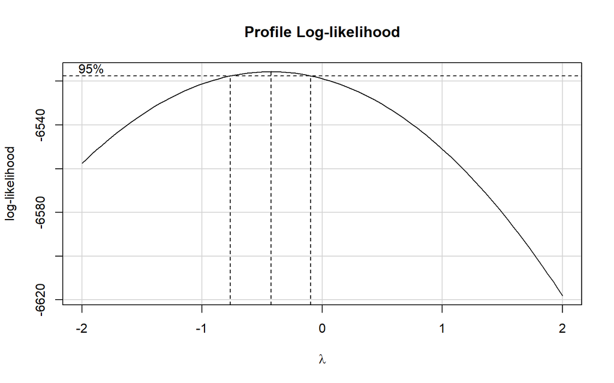

```r
lin_mod_simp %>% complete() %$% boxCox(Systolic_BP ~ Sodium + Potassium + Age + High_BP + Insomnia + Milk)
```

```r
lin_mod_simp %>% complete() %$% powerTransform(Systolic_BP ~ Sodium + Potassium + Age + High_BP + Insomnia + Milk)
```

```
Estimated transformation parameter
        Y1
-0.4295797
```

```r
lin_mod_simp_data = lin_mod_simp %>% complete() %>%
    mutate(inv_sbp = (1/Systolic_BP))
```

As a final assessment to demonstrate and verify that this outcome transformation appropriately removed the skew from the data, the normal q-q plot, histogram, and violin box-plot for both the unaltered and transformed outcomes have been provided below:

[figure not shown]

```r
a4 <- ggplot(lin_mod_simp_data, aes(x = "", y = 1/Systolic_BP)) +
  geom_violin(fill = "dodgerblue", alpha = 0.3) +
  geom_boxplot(width = 0.25, fill = "dodgerblue", notch = TRUE) +
  coord_flip() +
  labs(title = "Violin Boxplot: 1/SBP", x = "", y = "Inverse Systolic Blood Pressure (mm Hg)")

a5 <- ggplot(lin_mod_simp_data, aes(x = 1/Systolic_BP)) +
  geom_histogram(aes(y = stat(density)), bins = nclass.scott(1/lin_mod_simp_data$Systolic_BP), col = "white", fill = "dodgerblue") +
  stat_function(fun = dnorm, args = list(mean = mean(1/lin_mod_simp_data$Systolic_BP), sd = sd(1/lin_mod_simp_data$Systolic_BP)), col = "red", lwd = 1) +
  labs(title = "Density Function: 1/SBP", x = "Inverse Systolic Blood Pressure (mm Hg)")

a6 <- ggplot(lin_mod_simp_data, aes(sample = 1/Systolic_BP)) +
  geom_qq(col = "dodgerblue") +
  geom_qq_line(col = "red") +
  labs(title = "Normal Q-Q plot: 1/SBP", x = "", y = "Inverse Systolic Blood Pressure (mm Hg)")


(a3 + a2) / a1 +
  plot_layout(heights = c(5,2)) +
  plot_annotation(title = "Inverse Systolic Blood Pressure",
                  subtitle = "Distribution & Normality Assessment of subject's 3rd systolic blood pressure measurement,\n as taken with an oscillometric device",
                  caption = "All data above pulled from 2017-2018 NHANES datasets")
```

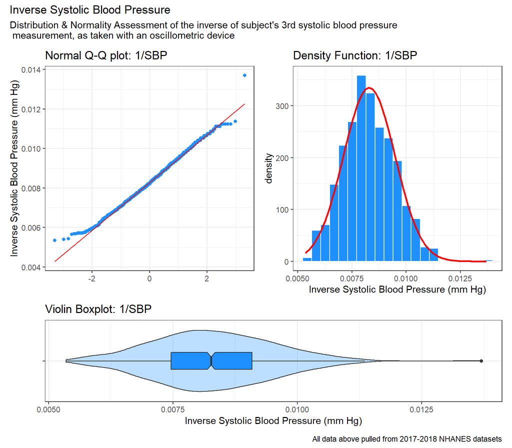

```r
(a6 + a5) / a4 +
  plot_layout(heights = c(5,2)) +
  plot_annotation(title = "Inverse Systolic Blood Pressure",
                  subtitle = "Distribution & Normality Assessment of the inverse of subject's 3rd systolic blood pressure\n measurement, as taken with an oscillometric device",
                  caption = "All data above pulled from 2017-2018 NHANES datasets")
```

While the outcome data does appear to have some outliers, this transformation appears to be largely appropriate, so this transformation will be used when generating the models below.

## 8.3 Scatterplot Matrix and Collinearity

The next step in the linear regression analysis will be to assess the variables for any collinearity. To accomplish this, a scatterplot matrix will be generated below:

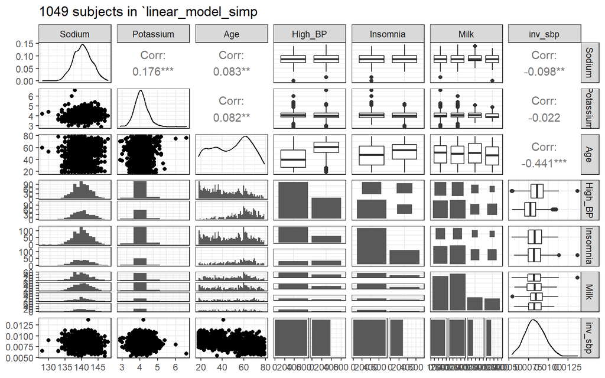

```r
ggpairs(lin_mod_simp_data %>% select(Sodium, Potassium, Age, High_BP, Insomnia, Milk, inv_sbp),
        lower = list(combo = wrap("facethist", binwidth = 1)),
        title = "1049 subjects in `linear_model_simp")
```

The results of the scatterplot matrix above suggest very little collinearity between any of the predictor variables, so removal of any predictor variables does not appear necessary. As a precaution, we can also examine the variance inflation factors with the code below:

```r
vif(lm(data = lin_mod_simp_data, inv_sbp ~ Sodium + Potassium + Age + High_BP + Insomnia + Milk))
```

```
              GVIF Df GVIF^(1/(2*Df))
Sodium    1.038079  1        1.018862
Potassium 1.057357  1        1.028279
Age       1.310541  1        1.144788
High_BP   1.344194  1        1.159394
Insomnia  1.053258  1        1.026284
Milk      1.024193  3        1.003992
```

Again, all of the variance inflation factors are well below 5, confirming the results of the scatterplot matrix examined above. With this accomplished, we can now proceed to generating our main effect model, **Model A**, which will be accomplished next.

## 8.4 Model A - the main effects model

In light of the outcome transformation and collinearity assessments performed above, two versions of **Model A** will be generated below using all of the prepared variables, one using an `lm` fit and the other an `ols` fit:

```r
model_a_lm = fit.mult.impute(1/Systolic_BP ~ Sodium + Potassium + Age + High_BP + Insomnia + Milk,
                    fitter = lm, xtrans = lin_mod_mimp,
                    data = lin_mod_data, x = TRUE, y = TRUE, pr = FALSE)

model_a_ols = fit.mult.impute(1/Systolic_BP ~ Sodium + Potassium + Age + High_BP + Insomnia + Milk,
                    fitter = ols, xtrans = lin_mod_mimp,
                    data = lin_mod_data, x = TRUE, y = TRUE, pr = FALSE)
```

The coefficients for **Model A** as taken from the `lm` fitted model have been provided below:

```r
tidy(model_a_lm, conf.int = 0.9) %>%
  select(term, estimate, std.error, p.value, conf.low, conf.high) %>%
  kable(digits = 7)
```

| term | estimate | std.error | p.value | conf.low | conf.high |
| --- | --- | --- | --- | --- | --- |
| (Intercept) | 0.0130170 | 0.0016825 | 0.0000000 | 0.0095468 | 0.0164872 |
| Sodium | -0.0000257 | 0.0000121 | 0.0341163 | -0.0000506 | -0.0000008 |
| Potassium | 0.0000242 | 0.0000887 | 0.7846849 | -0.0001562 | 0.0002047 |
| Age | -0.0000243 | 0.0000021 | 0.0000000 | -0.0000285 | -0.0000201 |
| High_BPYes | -0.0004853 | 0.0000781 | 0.0000000 | -0.0006383 | -0.0003322 |
| InsomniaYes | 0.0001590 | 0.0000741 | 0.0320039 | 0.0000136 | 0.0003044 |
| Milk2% Milk | 0.0000911 | 0.0000759 | 0.2306477 | -0.0000727 | 0.0002548 |
| Milk1% or Skim Milk | 0.0003042 | 0.0001025 | 0.0030626 | 0.0000813 | 0.0005270 |
| MilkSoy or Other Milk | 0.0000331 | 0.0001074 | 0.7577967 | -0.0002069 | 0.0002731 |

Additionally, the R^2, adjusted R^2, AIC, and BIC values for the `lm` fitted model have been provided below through the use of the `glance` function:

```r
glance_mod_a = glance(model_a_lm) %>%
    select(r.squared, adj.r.squared, sigma, AIC, BIC) %>%
    kable(digits = c(3, 3, 3, 1, 1))

glance_mod_a
```

| r.squared | adj.r.squared | sigma | AIC | BIC |
| --- | --- | --- | --- | --- |
| 0.232 | 0.226 | 0.001 | -11405.4 | -11355.9 |

```r
set.seed(43202)
validate(model_a_ols)
```

```
          index.orig training   test optimism index.corrected  n
R-square      0.2320   0.2345 0.2249   0.0096          0.2224 40
MSE           0.0000   0.0000 0.0000   0.0000          0.0000 40
g             0.0007   0.0007 0.0007   0.0000          0.0007 40
Intercept     0.0000   0.0000 0.0002  -0.0002          0.0002 40
Slope         1.0000   1.0000 0.9810   0.0190          0.9810 40
```

A Nomogram has been generated for this model as well, which also includes a back transformation for determining a person’s systolic blood pressure as predicted by this model:

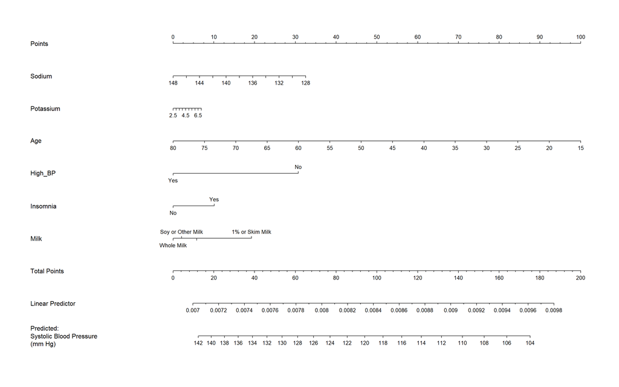

```r
plot(nomogram(model_a_ols,
              fun = list(function(x) 1/x ),
              funlabel = "Predicted:\nSystolic Blood Pressure\n(mm Hg)",
              fun.at = seq(60, 200, 2)))
```

Lastly, the residual plots for the `lm` fitted version of **Model A** have been provided below:

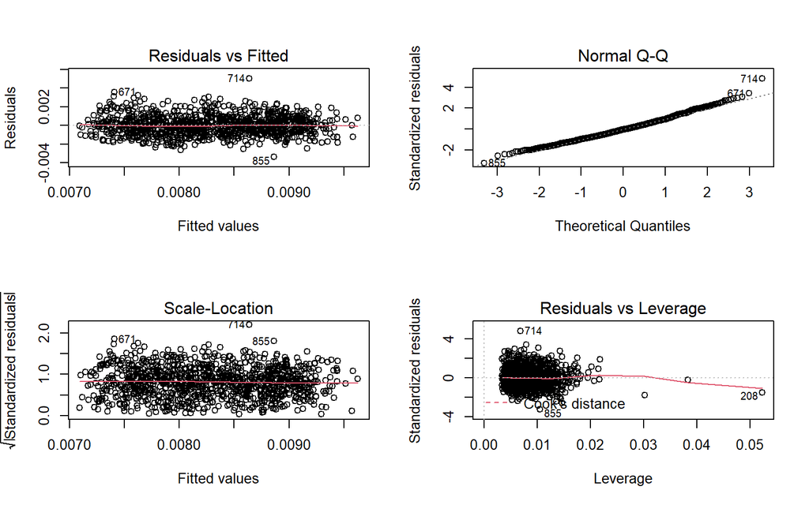

```r
par(mfrow = c(2,2)); plot(model_a_lm); par(mfrow = c(1,1))
```

Regarding these residual plots, it’s worth noting that there doesn’t appear to be any serious issues with linearity or constant variance, however we do appear to have some unusually high residuals as seen in the normal q-q plot, and some points with unusually high leverage, as seen in the residuals vs leverage plot. These samples, particularly the notable outliers like point 714, warrant further investigation, however as this is beyond the scope of the project they will not be addressed at this time.

## 8.5 Non-Linearity

Now that the initial model has been generated, we should examine whether or not it would be prudent to consider non-linear terms for this model. To accomplish this, a Spearman p2 Plot has been generated below:

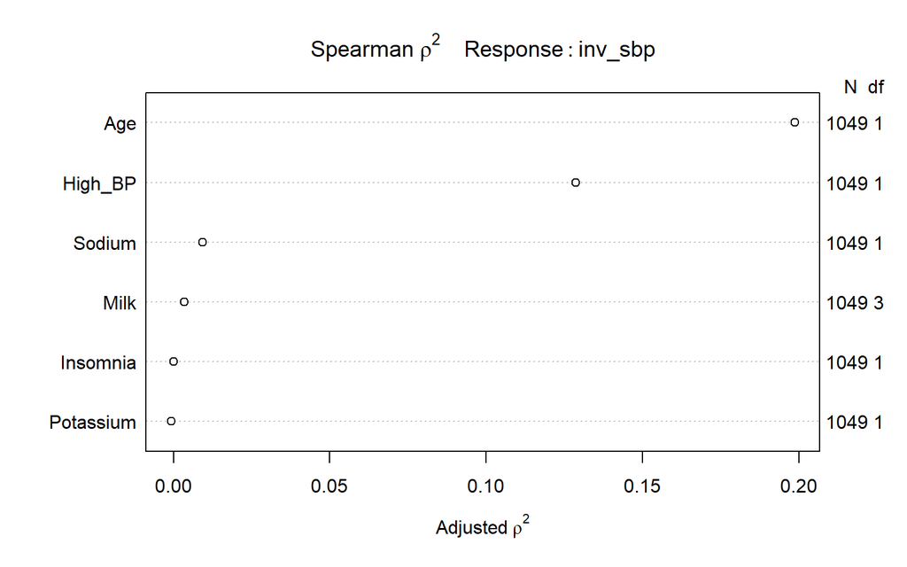

```r
spear_lin_mod = spearman2(inv_sbp ~ Sodium + Potassium + Age + High_BP + Insomnia + Milk, data = lin_mod_simp_data)

plot(spear_lin_mod)
```

From the model above, we can clearly see that if we are to spend any degrees of freedom on non-linear terms, the best option would be to choose the `Age` variable, followed by the `High_BP` variable, and then the `Sodium` variable. As such, we will create a linear model with non-linear terms for these 3 variables in the next section.

## 8.6 Model B - the augmented model

In light of the non-linearity assessment performed in the previous section, two versions of model b will be generated, one using an `lm` fit and the other an `ols` fit, each using 3 non-linear terms - specifically restricted cubic splines for `Age` and `Sodium`, and an interaction term between `High_BP` and `Sodium`:

```r
model_b_lm = fit.mult.impute(1/Systolic_BP ~ Potassium + rcs(Sodium, 4) + rcs(Age, 5) + High_BP + High_BP %ia% Sodium + Insomnia + Milk, fitter = lm, xtrans = lin_mod_mimp, data = lin_mod_data, x = TRUE, y = TRUE, pr = FALSE)
model_b_ols = fit.mult.impute(1/Systolic_BP ~ Potassium + rcs(Sodium, 4) + rcs(Age, 5) + High_BP + High_BP %ia% Sodium + Insomnia + Milk, fitter = ols, xtrans = lin_mod_mimp, data = lin_mod_data, x = TRUE, y = TRUE, pr = FALSE)
```

The coefficients for **Model B** as taken from the `lm` fitted model have been provided below:

```r
tidy(model_b_lm, conf.int = 0.9) %>%
  select(term, estimate, std.error, p.value, conf.low, conf.high) %>%
  kable(digits = 7)
```

| term | estimate | std.error | p.value | conf.low | conf.high |
| --- | --- | --- | --- | --- | --- |
| (Intercept) | 0.0093050 | 0.0059171 | 0.1161262 | -0.0027760 | 0.0213860 |
| Potassium | -0.0000009 | 0.0000906 | 0.9922571 | -0.0001851 | 0.0001833 |
| rcs(Sodium, 4)Sodium | 0.0000016 | 0.0000429 | 0.9701299 | -0.0000860 | 0.0000892 |
| rcs(Sodium, 4)Sodium’ | 0.0000004 | 0.0001540 | 0.9980048 | -0.0003122 | 0.0003130 |
| rcs(Sodium, 4)Sodium’’ | -0.0001914 | 0.0005657 | 0.7351062 | -0.0013367 | 0.0009538 |
| rcs(Age, 5)Age | -0.0000229 | 0.0000123 | 0.0625507 | -0.0000470 | 0.0000012 |
| rcs(Age, 5)Age’ | 0.0000056 | 0.0000587 | 0.9234304 | -0.0001095 | 0.0001208 |
| rcs(Age, 5)Age’’ | -0.0000537 | 0.0001824 | 0.7684030 | -0.0004118 | 0.0003043 |
| rcs(Age, 5)Age’’’ | 0.0002351 | 0.0003289 | 0.4748663 | -0.0004106 | 0.0008808 |
| High_BPYes | -0.0007382 | 0.0034556 | 0.8308789 | -0.0077242 | 0.0062478 |
| High_BP %ia% Sodium | 0.0000018 | 0.0000246 | 0.9406354 | -0.0000480 | 0.0000516 |
| InsomniaYes | 0.0001650 | 0.0000743 | 0.0265336 | 0.0000191 | 0.0003109 |
| Milk2% Milk | 0.0000874 | 0.0000763 | 0.2519472 | -0.0000770 | 0.0002519 |
| Milk1% or Skim Milk | 0.0002926 | 0.0001032 | 0.0046870 | 0.0000683 | 0.0005169 |
| MilkSoy or Other Milk | 0.0000290 | 0.0001077 | 0.7875336 | -0.0002120 | 0.0002701 |

Additionally, the R^2, adjusted R^2, AIC, and BIC values for the `lm` fitted model have been provided below:

```r
glance(model_b_lm) %>%
    select(r.squared, adj.r.squared, sigma, AIC, BIC) %>%
    kable(digits = c(3, 3, 3, 1, 1))
```

| r.squared | adj.r.squared | sigma | AIC | BIC |
| --- | --- | --- | --- | --- |
| 0.236 | 0.225 | 0.001 | -11398.2 | -11319 |

The following code generates an appropriate nomogram for **Model B**:

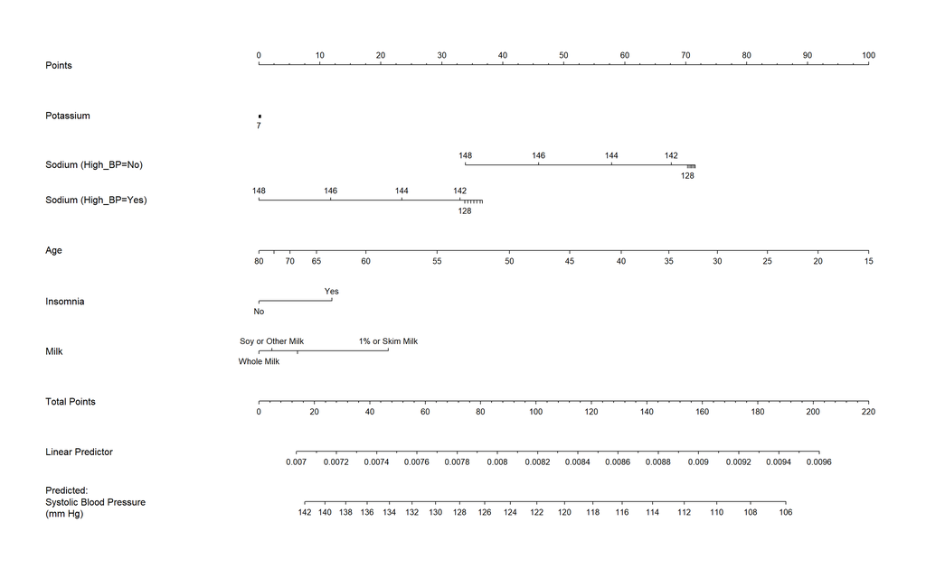

```r
plot(nomogram(model_b_ols,
              fun = list(function(x) 1/x ),
              funlabel = "Predicted:\nSystolic Blood Pressure\n(mm Hg)",
              fun.at = seq(60, 200, 2)))
```

An analysis of variance table has been generated so both models can be compared to one another:

```r
anova(model_a_lm, model_b_lm)
```

```
Analysis of Variance Table

Model 1: 1/Systolic_BP ~ Sodium + Potassium + Age + High_BP + Insomnia +
    Milk
Model 2: 1/Systolic_BP ~ Potassium + rcs(Sodium, 4) + rcs(Age, 5) + High_BP +
    High_BP %ia% Sodium + Insomnia + Milk
  Res.Df       RSS Df  Sum of Sq      F Pr(>F)
1   1040 0.0011431
2   1034 0.0011379  6 5.2324e-06 0.7925 0.5759
```

Lastly, the residual plots for the `lm` fitted version of **Model B** have been provided below:

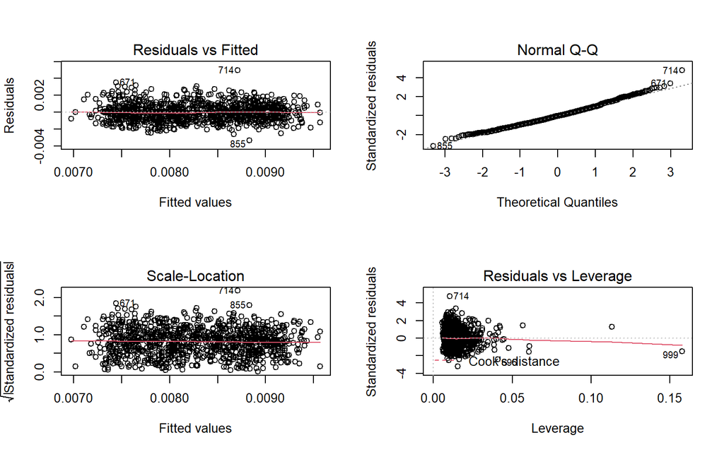

```r
par(mfrow = c(2,2)); plot(model_b_lm); par(mfrow = c(1,1))
```

Just as with **Model A**, it’s worth noting that there doesn’t appear to be any serious issues with linearity or constant variance, however we do appear to once again have some unusually high residuals as seen in the normal q-q plot, and some points with unusually high leverage, as seen in the residuals vs leverage plot. These samples, particularly the notable outliers like point 714, warrant further investigation, however as this is beyond the scope of the project they will not be addressed at this time. Additionally, the residual plots for both models have been provided below for easy comparison between the two:

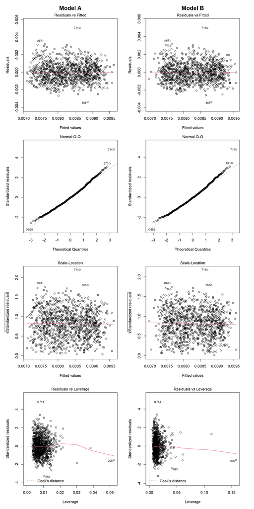

```r
par(mfrow=c(4,2), mar=c(4, 4, 3, 2) + 0.1, cex=1, cex.main = 1.5, oma=c(0, 1, 0.9, 1))
plot(model_a_lm, which = 1, main="Model A\n")
plot(model_b_lm, which = 1, main="Model B\n")
par(mar=c(5, 4, 2, 2) + 0.1)
plot(model_a_lm, which = 2)
plot(model_b_lm, which = 2)
plot(model_a_lm, which = 3)
plot(model_b_lm, which = 3)
plot(model_a_lm, which = 5)
plot(model_b_lm, which = 5)
```

## 8.7 Validating the Models

Although both of the following have already been provided above, the validated R-square statistics have been generated and provided again below for comparison between the two models:

```r
set.seed(43202)
validate(model_a_ols)
```

```
          index.orig training   test optimism index.corrected  n
R-square      0.2320   0.2345 0.2249   0.0096          0.2224 40
MSE           0.0000   0.0000 0.0000   0.0000          0.0000 40
g             0.0007   0.0007 0.0007   0.0000          0.0007 40
Intercept     0.0000   0.0000 0.0002  -0.0002          0.0002 40
Slope         1.0000   1.0000 0.9810   0.0190          0.9810 40
```

```r
validate(model_b_ols)
```

```
          index.orig training   test optimism index.corrected  n
R-square      0.2355   0.2498 0.2232   0.0266          0.2089 40
MSE           0.0000   0.0000 0.0000   0.0000          0.0000 40
g             0.0007   0.0007 0.0007   0.0000          0.0006 40
Intercept     0.0000   0.0000 0.0004  -0.0004          0.0004 40
Slope         1.0000   1.0000 0.9556   0.0444          0.9556 40
```

```r
comp_table = bind_rows( glance(model_a_lm), glance(model_b_lm) ) %>%
  mutate(mod = c("Model A", "Model B"))

comp_table %>% select(mod, r.squared, adj.r.squared, sigma, AIC, BIC) %>%
  kable(dig = c(0, 3, 3, 3, 1, 1))
```

| mod | r.squared | adj.r.squared | sigma | AIC | BIC |
| --- | --- | --- | --- | --- | --- |
| Model A | 0.232 | 0.226 | 0.001 | -11405.4 | -11355.9 |
| Model B | 0.236 | 0.225 | 0.001 | -11398.2 | -11319.0 |

## 8.8 Final Model

The parameters for **Model A**, along with the point estimates for the `lm` version of the model have been provided below:

```r
summary(model_a_lm, conf.int = 0.9)
```

```
Call:
fit.mult.impute(formula = 1/Systolic_BP ~ Sodium + Potassium +
    Age + High_BP + Insomnia + Milk, fitter = lm, xtrans = lin_mod_mimp,
    data = lin_mod_data, pr = FALSE, x = TRUE, y = TRUE)

Residuals:
       Min         1Q     Median         3Q        Max
-0.0033843 -0.0007320 -0.0000426  0.0006464  0.0050391

Coefficients:
                        Estimate Std. Error t value Pr(>|t|)
(Intercept)            1.302e-02  1.683e-03   7.737 2.41e-14 ***
Sodium                -2.568e-05  1.211e-05  -2.121  0.03412 *
Potassium              2.424e-05  8.870e-05   0.273  0.78468
Age                   -2.430e-05  2.125e-06 -11.433  < 2e-16 ***
High_BPYes            -4.853e-04  7.815e-05  -6.210 7.65e-10 ***
InsomniaYes            1.590e-04  7.406e-05   2.147  0.03200 *
Milk2% Milk            9.106e-05  7.592e-05   1.199  0.23065
Milk1% or Skim Milk    3.042e-04  1.025e-04   2.968  0.00306 **
MilkSoy or Other Milk  3.312e-05  1.074e-04   0.308  0.75780
---
Signif. codes:  0 '***' 0.001 '**' 0.01 '*' 0.05 '.' 0.1 ' ' 1

Residual standard error: 0.001048 on 1040 degrees of freedom
Multiple R-squared:  0.2323,    Adjusted R-squared:  0.2264
F-statistic: 39.34 on 8 and 1040 DF,  p-value: < 2.2e-16
```

```r
tidy(model_a_lm, conf.int = 0.9) %>%
  select(term, estimate, std.error, p.value, conf.low, conf.high) %>%
  kable(digits = 7)
```

| term | estimate | std.error | p.value | conf.low | conf.high |
| --- | --- | --- | --- | --- | --- |
| (Intercept) | 0.0130170 | 0.0016825 | 0.0000000 | 0.0095468 | 0.0164872 |
| Sodium | -0.0000257 | 0.0000121 | 0.0341163 | -0.0000506 | -0.0000008 |
| Potassium | 0.0000242 | 0.0000887 | 0.7846849 | -0.0001562 | 0.0002047 |
| Age | -0.0000243 | 0.0000021 | 0.0000000 | -0.0000285 | -0.0000201 |
| High_BPYes | -0.0004853 | 0.0000781 | 0.0000000 | -0.0006383 | -0.0003322 |
| InsomniaYes | 0.0001590 | 0.0000741 | 0.0320039 | 0.0000136 | 0.0003044 |
| Milk2% Milk | 0.0000911 | 0.0000759 | 0.2306477 | -0.0000727 | 0.0002548 |
| Milk1% or Skim Milk | 0.0003042 | 0.0001025 | 0.0030626 | 0.0000813 | 0.0005270 |
| MilkSoy or Other Milk | 0.0000331 | 0.0001074 | 0.7577967 | -0.0002069 | 0.0002731 |

Additionally, the parameters for **Model A**, along with the point estimates for the `ols` version of the model have been provided below:

```r
model_a_ols
```

```
Linear Regression Model

 fit.mult.impute(formula = 1/Systolic_BP ~ Sodium + Potassium +
     Age + High_BP + Insomnia + Milk, fitter = ols, xtrans = lin_mod_mimp,
     data = lin_mod_data, pr = FALSE, x = TRUE, y = TRUE)

                 Model Likelihood    Discrimination
                       Ratio Test           Indexes
 Obs    1049    LR chi2    280.42    R2       0.235
 sigma0.0010    d.f.            8    R2 adj   0.229
 d.f.   1040    Pr(> chi2) 0.0000    g        0.001

 Residuals

        Min         1Q     Median         3Q        Max
 -0.0033843 -0.0007320 -0.0000426  0.0006464  0.0050391


                        Coef    S.E.   t      Pr(>|t|)
 Intercept               0.0130 0.0018   7.36 <0.0001
 Sodium                  0.0000 0.0000  -2.02 0.0433
 Potassium               0.0000 0.0001   0.26 0.7921
 Age                     0.0000 0.0000 -11.43 <0.0001
 High_BP=Yes            -0.0005 0.0001  -6.22 <0.0001
 Insomnia=Yes            0.0002 0.0001   2.15 0.0321
 Milk=2% Milk            0.0001 0.0001   1.09 0.2755
 Milk=1% or Skim Milk    0.0003 0.0001   2.68 0.0075
 Milk=Soy or Other Milk  0.0000 0.0001   0.27 0.7866
```

```r
summary(model_a_ols, conf.int = 0.9)
```

```
             Effects              Response : 1/Systolic_BP

 Factor                           Low   High  Diff. Effect      S.E.
 Sodium                           138.0 142.0  4.0  -1.0272e-04 5.0772e-05
 Potassium                          3.8   4.3  0.5   1.2121e-05 4.5979e-05
 Age                               33.0  63.0 30.0  -7.2904e-04 6.3806e-05
 High_BP - Yes:No                   1.0   2.0   NA  -4.8528e-04 7.7992e-05
 Insomnia - Yes:No                  1.0   2.0   NA   1.5902e-04 7.4085e-05
 Milk - Whole Milk:2% Milk          2.0   1.0   NA  -9.1059e-05 8.3456e-05
 Milk - 1% or Skim Milk:2% Milk     2.0   3.0   NA   2.1313e-04 1.1386e-04
 Milk - Soy or Other Milk:2% Milk   2.0   4.0   NA  -5.7936e-05 1.2222e-04
 Lower 0.9   Upper 0.9
 -1.8631e-04 -1.9132e-05
 -6.3576e-05  8.7817e-05
 -8.3409e-04 -6.2400e-04
 -6.1368e-04 -3.5688e-04
  3.7054e-05  2.8099e-04
 -2.2845e-04  4.6336e-05
  2.5684e-05  4.0058e-04
 -2.5915e-04  1.4328e-04
```

The effect sizes have been plotted below to demonstrate them visually:

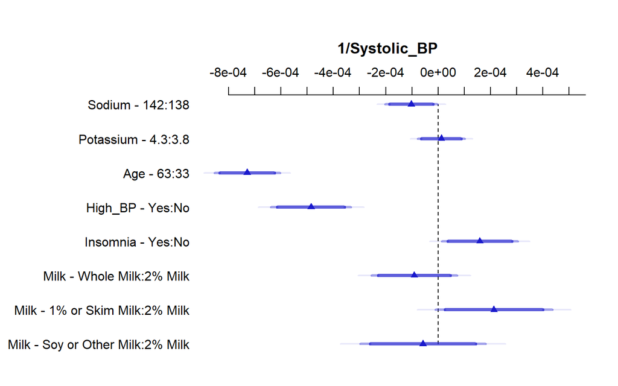

```r
par(mar=c(2, 4, 4, 2) + 0.1)
plot(summary(model_a_ols))
```

The index/optimism corrected R^2 value, as can be seen again below via the `validate` function, is approximately 0.2224:

```r
set.seed(43202)
validate(model_a_ols)
```

```
          index.orig training   test optimism index.corrected  n
R-square      0.2320   0.2345 0.2249   0.0096          0.2224 40
MSE           0.0000   0.0000 0.0000   0.0000          0.0000 40
g             0.0007   0.0007 0.0007   0.0000          0.0007 40
Intercept     0.0000   0.0000 0.0002  -0.0002          0.0002 40
Slope         1.0000   1.0000 0.9810   0.0190          0.9810 40
```

Lastly, the nomogram for **Model A** has once again been provided below:

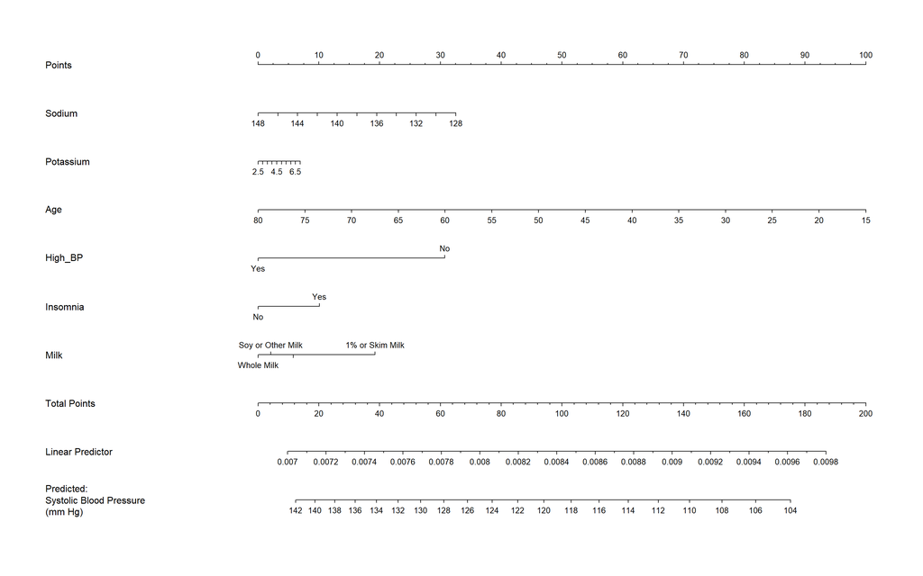

```r
plot(nomogram(model_a_ols,
              fun = list(function(x) 1/x ),
              funlabel = "Predicted:\nSystolic Blood Pressure\n(mm Hg)",
              fun.at = seq(60, 200, 2)))
```

# 9 Logistic Regression Modeling

## 9.1 Missingness

As with the linear regression models examined above, the missingness from the `analysis_data` dataset will be dealt with via multiple imputation. However, since there is no data missing from the `High_BP` outcome variable, we will not filter any samples out, but will instead impute all missing values. As with the imputation steps in the linear regression analyses, the `mice` package will once again be used to create both the single and multiple imputation data necessary to perform this logistic regression analysis. In this logistic regression analysis, single imputation will be performed for use in determining what non-linear terms to consider / add to our augmented model, **Model Z**.

### 9.1.1 Single Imputation

The code necessary for performing the single imputation for this data is provided below:

```r
set.seed(43202)
dd = datadist(analysis_data)
options(datadist = "dd")

log_mod_simp = analysis_data %>%
  select(Systolic_BP, Sodium, Potassium, Age, High_BP, Insomnia, Milk) %>%
  mice(., m = 1, method = c("midastouch", "midastouch", "midastouch", "", "", "", "cart"), printFlag = FALSE)
```

With this accomplished, the creation of the multiple imputation data may now proceed.

### 9.1.2 Multiple Imputation

```r
set.seed(43202)
dd = datadist(analysis_data)
options(datadist = "dd")

log_mod_mimp = analysis_data %>%
  select(Systolic_BP, Sodium, Potassium, Age, High_BP, Insomnia, Milk) %>%
  mice(., m = 25, method = c("midastouch", "midastouch", "midastouch", "", "", "", "cart"), printFlag = FALSE)
```

## 9.2 Model Y

Now that the missing data has been addressed, the imputed data can be used along with the `analysis_data` dataset to produce the main effects model, **Model Y** for this regression analysis. As with the linear regression analysis, two variants of the model will be generated, however this time by using the `glm` and `lrm` fitting methods for the models:

```r
set.seed(43202)
dd = datadist(analysis_data)
options(datadist = "dd")

model_y_glm = fit.mult.impute(High_BP == "Yes" ~ Systolic_BP + Potassium + Sodium + Age + Insomnia + Milk, fitter = glm, xtrans = log_mod_mimp, data = analysis_data, x = TRUE, y = TRUE, pr = FALSE)
model_y_lrm = fit.mult.impute(High_BP == "Yes" ~ Systolic_BP + Potassium + Sodium + Age + Insomnia + Milk, fitter = lrm, xtrans = log_mod_mimp, data = analysis_data, x = TRUE, y = TRUE, pr = FALSE)
```

With the models generated, the coefficients for both variants of **Model Y** have been displayed below:

```r
tidy(model_y_glm, conf.int = 0.9) %>%
  select(term, estimate, std.error, p.value, conf.low, conf.high) %>%
  kable(digits = 3)
```

| term | estimate | std.error | p.value | conf.low | conf.high |
| --- | --- | --- | --- | --- | --- |
| (Intercept) | 0.059 | 0.610 | 0.923 | -1.018 | 1.373 |
| Systolic_BP | 0.005 | 0.001 | 0.000 | 0.003 | 0.006 |
| Potassium | -0.085 | 0.032 | 0.008 | -0.152 | -0.026 |
| Sodium | -0.004 | 0.004 | 0.422 | -0.013 | 0.004 |
| Age | 0.010 | 0.001 | 0.000 | 0.009 | 0.012 |
| InsomniaYes | 0.168 | 0.027 | 0.000 | 0.110 | 0.215 |
| Milk2% Milk | 0.022 | 0.028 | 0.426 | -0.024 | 0.084 |
| Milk1% or Skim Milk | 0.050 | 0.037 | 0.181 | -0.007 | 0.140 |
| MilkSoy or Other Milk | -0.059 | 0.039 | 0.129 | -0.132 | 0.019 |

```r
model_y_lrm
```

```
Logistic Regression Model

 fit.mult.impute(formula = High_BP == "Yes" ~ Systolic_BP + Potassium +
     Sodium + Age + Insomnia + Milk, fitter = lrm, xtrans = log_mod_mimp,
     data = analysis_data, pr = FALSE, x = TRUE, y = TRUE)

                        Model Likelihood    Discrimination    Rank Discrim.
                              Ratio Test           Indexes          Indexes
 Obs          1200    LR chi2     394.55    R2       0.384    C       0.823
  FALSE        767    d.f.             8    g        1.726    Dxy     0.647
  TRUE         433    Pr(> chi2) <0.0001    gr       5.622    gamma   0.647
 max |deriv| 2e-07                          gp       0.299    tau-a   0.299
                                            Brier    0.164

                        Coef    S.E.   Wald Z Pr(>|Z|)
 Intercept              -1.4588 3.9071 -0.37  0.7089
 Systolic_BP             0.0269 0.0047  5.73  <0.0001
 Potassium              -0.5500 0.1968 -2.79  0.0052
 Sodium                 -0.0264 0.0282 -0.94  0.3486
 Age                     0.0618 0.0053 11.74  <0.0001
 Insomnia=Yes            0.9575 0.1570  6.10  <0.0001
 Milk=2% Milk            0.1095 0.1837  0.60  0.5512
 Milk=1% or Skim Milk    0.3010 0.2581  1.17  0.2436
 Milk=Soy or Other Milk -0.4178 0.2736 -1.53  0.1267
```

Additionally, the Nagelkerke R^2 for the `lrm` variant of this model is approximately 0.3679, as shown with the code below:

```r
set.seed(43202)
validate(model_y_lrm)
```

```
          index.orig training    test optimism index.corrected  n
Dxy           0.6441   0.6531  0.6401   0.0130          0.6311 40
R2            0.3840   0.3938  0.3776   0.0162          0.3679 40
Intercept     0.0000   0.0000 -0.0106   0.0106         -0.0106 40
Slope         1.0000   1.0000  0.9649   0.0351          0.9649 40
Emax          0.0000   0.0000  0.0096   0.0096          0.0096 40
D             0.3280   0.3382  0.3214   0.0168          0.3112 40
U            -0.0017  -0.0017  0.0005  -0.0021          0.0005 40
Q             0.3296   0.3398  0.3209   0.0189          0.3107 40
B             0.1644   0.1620  0.1658  -0.0039          0.1683 40
g             1.7265   1.7805  1.7065   0.0739          1.6525 40
gp            0.2989   0.3022  0.2962   0.0060          0.2929 40
```

The following provides the necessary code to generate the ROC curve plot for the `lrm` version of **Model Y**:

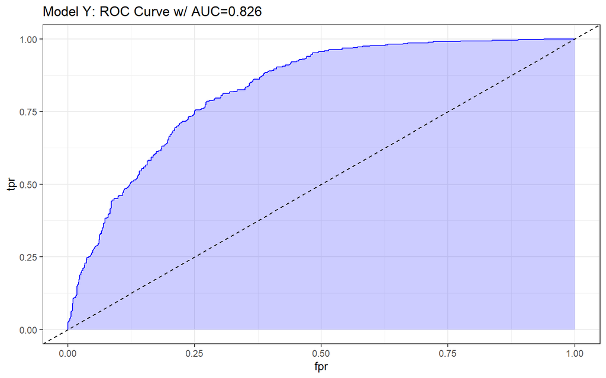

```r
prob = predict(model_y_lrm, type="fitted")
pred = prediction(prob, analysis_data$High_BP == "Yes")
perf = performance(pred, measure = "tpr", x.measure = "fpr")
auc = performance(pred, measure="auc")

auc = round(auc@y.values[[1]],3)
roc.data = data.frame(fpr=unlist(perf@x.values),
                       tpr = unlist(perf@y.values),
                       model="LRM")

ggplot(roc.data, aes(x = fpr, ymin = 0, ymax = tpr)) +
  geom_ribbon(alpha = 0.2, fill = "blue") +
  geom_line(aes(y = tpr), col = "blue") +
  geom_abline(intercept = 0, slope = 1, lty = "dashed") +
  labs(title = paste0("Model Y: ROC Curve w/ AUC=", auc))
```

In order to generate a confusion matrix for **Model Y**, the `glm` version of the model will need to be augmented as follows:

```r
model_y_aug = augment(model_y_glm, type.predict = "response")
```

With the `glm` variant of **Model Y** augmented, the following provides the code necessary to produce the confusion matrix for **Model Y**:

```r
confuse_model_y = model_y_aug %>%
  mutate(High_BP_obs = factor(`High_BP == "Yes"` == "TRUE"),
         High_BP_pred = factor(.fitted >= 0.50),
         High_BP_obs = fct_relevel(High_BP_obs, "TRUE"),
         High_BP_pred = fct_relevel(High_BP_pred, "TRUE")) %$%
  table(High_BP_pred, High_BP_obs)
confuse_model_y
```

```
            High_BP_obs
High_BP_pred TRUE FALSE
       TRUE   262   140
       FALSE  171   627
```

From the confusion matrix above, we can see that for this model the specificity = 627/(627 + 140) = 0.817 = 81.7 %, the sensitivity = 262/(262 + 171) = 0.605 = 60.5 %, and the positive predictive value (i.e. precision) = 262/(262 + 140) = 0.652 = 65.2 %.

The following code generates an appropriate nomogram for **Model Y**:

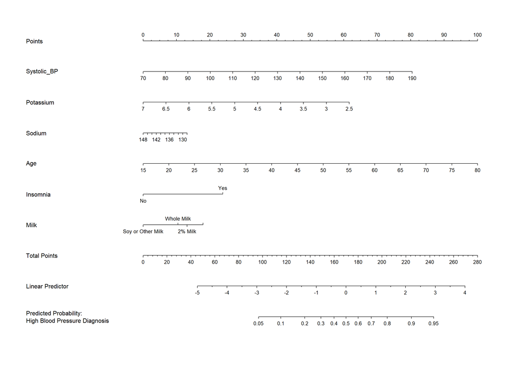

```r
plot(nomogram(model_y_lrm,
              fun = plogis,
              fun.at=c(0.05, seq(0.1, 0.9, by = 0.1), 0.95),
              funlabel = "Predicted Probability:\nHigh Blood Pressure Diagnosis"))
```

## 9.3 Non-Linearity

As was done with the linear regression analysis, we should examine whether or not it would be prudent to consider non-linear terms, now that the main effects model Model Y has been generated. To accomplish this, a Spearman p2 Plot has been generated below:

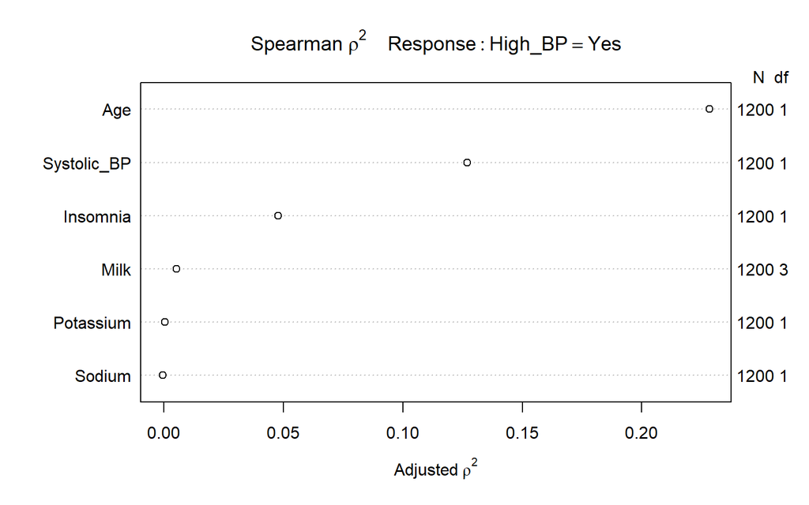

```r
spear_log_mod = spearman2(High_BP == "Yes" ~ Systolic_BP + Sodium + Potassium + Age + Insomnia + Milk, data = complete(log_mod_simp))

plot(spear_log_mod)
```

As was the case with the linear regression analysis for predicting inverse systolic blood pressure, the `Age` variable appears to be the most ideal variable to spend additional degrees of freedom on if we wish to consider the addition of non-linear terms, followed by the `Systolic_BP` as the next most likely. Considering that we have a limit of 6 additional degrees of freedom over our main effects model, we will prioritize the use of the these degrees of freedom by using non-linear terms for the `Age` and `Systolic_BP` variables for our augmented model, **Model Z**, in the next section.

## 9.4 Model Z

In light of the non-linearity assessment performed in the previous section, two versions of model z will be generated, one using an glm fit and the other an lrm fit, with both incorporating non-linear terms for `Age` and `Systolic_BP`:

```r
model_z_glm = fit.mult.impute(High_BP == "Yes" ~ rcs(Systolic_BP, 5) + Potassium + Sodium + rcs(Age, 5) + Insomnia + Milk, fitter = glm, xtrans = log_mod_mimp, data = analysis_data, x = TRUE, y = TRUE, pr = FALSE)
model_z_lrm = fit.mult.impute(High_BP == "Yes" ~ rcs(Systolic_BP, 5) + Potassium + Sodium + rcs(Age, 5) + Insomnia + Milk, fitter = lrm, xtrans = log_mod_mimp, data = analysis_data, x = TRUE, y = TRUE, pr = FALSE)
```

With the models generated, the coefficients for both variants of **Model Z** have been displayed below:

```r
tidy(model_z_glm, conf.int = 0.9) %>%
  select(term, estimate, std.error, p.value, conf.low, conf.high) %>%
  kable(digits = 3)
```

| term | estimate | std.error | p.value | conf.low | conf.high |
| --- | --- | --- | --- | --- | --- |
| (Intercept) | 0.637 | 0.761 | 0.403 | -0.760 | 2.223 |
| rcs(Systolic_BP, 5)Systolic_BP | 0.002 | 0.004 | 0.707 | -0.007 | 0.010 |
| rcs(Systolic_BP, 5)Systolic_BP’ | 0.006 | 0.033 | 0.857 | -0.062 | 0.068 |
| rcs(Systolic_BP, 5)Systolic_BP’’ | 0.046 | 0.129 | 0.724 | -0.200 | 0.307 |
| rcs(Systolic_BP, 5)Systolic_BP’’’ | -0.151 | 0.161 | 0.347 | -0.465 | 0.165 |
| Potassium | -0.091 | 0.032 | 0.005 | -0.159 | -0.032 |
| Sodium | -0.004 | 0.004 | 0.380 | -0.013 | 0.004 |
| rcs(Age, 5)Age | 0.004 | 0.005 | 0.395 | -0.005 | 0.013 |
| rcs(Age, 5)Age’ | 0.021 | 0.024 | 0.393 | -0.028 | 0.066 |
| rcs(Age, 5)Age’’ | -0.044 | 0.069 | 0.523 | -0.172 | 0.099 |
| rcs(Age, 5)Age’’’ | 0.043 | 0.110 | 0.700 | -0.191 | 0.242 |
| InsomniaYes | 0.172 | 0.027 | 0.000 | 0.112 | 0.217 |
| Milk2% Milk | 0.021 | 0.028 | 0.445 | -0.026 | 0.082 |
| Milk1% or Skim Milk | 0.049 | 0.038 | 0.190 | -0.008 | 0.139 |
| MilkSoy or Other Milk | -0.057 | 0.039 | 0.141 | -0.131 | 0.021 |

```r
model_z_lrm
```

```
Logistic Regression Model

 fit.mult.impute(formula = High_BP == "Yes" ~ rcs(Systolic_BP,
     5) + Potassium + Sodium + rcs(Age, 5) + Insomnia + Milk,
     fitter = lrm, xtrans = log_mod_mimp, data = analysis_data,
     pr = FALSE, x = TRUE, y = TRUE)

                        Model Likelihood    Discrimination    Rank Discrim.
                              Ratio Test           Indexes          Indexes
 Obs          1200    LR chi2     403.89    R2       0.392    C       0.825
  FALSE        767    d.f.            14    g        1.815    Dxy     0.651
  TRUE         433    Pr(> chi2) <0.0001    gr       6.145    gamma   0.651
 max |deriv| 1e-08                          gp       0.302    tau-a   0.300
                                            Brier    0.163

                        Coef    S.E.   Wald Z Pr(>|Z|)
 Intercept              -1.7014 5.3529 -0.32  0.7506
 Systolic_BP             0.0186 0.0317  0.59  0.5568
 Systolic_BP'            0.0362 0.2314  0.16  0.8758
 Systolic_BP''           0.1249 0.8725  0.14  0.8862
 Systolic_BP'''         -0.5652 1.0457 -0.54  0.5889
 Potassium              -0.5305 0.1986 -2.67  0.0075
 Sodium                 -0.0281 0.0283 -0.99  0.3216
 Age                     0.0999 0.0450  2.22  0.0263
 Age'                   -0.0941 0.1912 -0.49  0.6225
 Age''                   0.1411 0.5054  0.28  0.7801
 Age'''                  0.0859 0.7012  0.12  0.9025
 Insomnia=Yes            0.9667 0.1587  6.09  <0.0001
 Milk=2% Milk            0.1251 0.1846  0.68  0.4979
 Milk=1% or Skim Milk    0.3307 0.2609  1.27  0.2049
 Milk=Soy or Other Milk -0.3924 0.2735 -1.43  0.1514
```

The necessary code for generating the plotted effects estimates has been provided below:

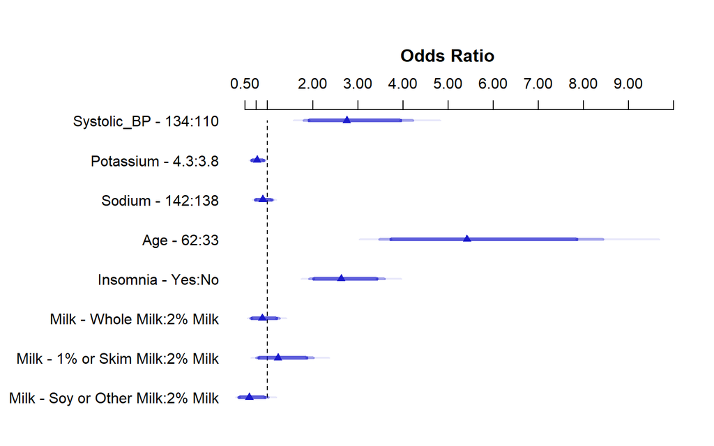

```r
par(mar=c(2, 4, 4, 2) + 0.1)
plot(summary(model_z_lrm))
```

As with **Model Y**, the Nagelkerke R^2 for the `lrm` variant of this model has been provided using the code below, which shows it to be approximately 0.3664:

```r
set.seed(43202)
validate(model_z_lrm)
```

```
          index.orig training    test optimism index.corrected  n
Dxy           0.6470   0.6597  0.6385   0.0212          0.6258 40
R2            0.3917   0.4032  0.3779   0.0253          0.3664 40
Intercept     0.0000   0.0000 -0.0167   0.0167         -0.0167 40
Slope         1.0000   1.0000  0.9427   0.0573          0.9427 40
Emax          0.0000   0.0000  0.0158   0.0158          0.0158 40
D             0.3357   0.3479  0.3217   0.0261          0.3096 40
U            -0.0017  -0.0017  0.0009  -0.0026          0.0009 40
Q             0.3374   0.3496  0.3208   0.0287          0.3087 40
B             0.1635   0.1601  0.1659  -0.0058          0.1693 40
g             1.8155   1.8866  1.7639   0.1227          1.6928 40
gp            0.3016   0.3053  0.2957   0.0096          0.2920 40
```

The following provides the necessary code to generate the ROC curve plot for the `lrm` version of **Model Z**:

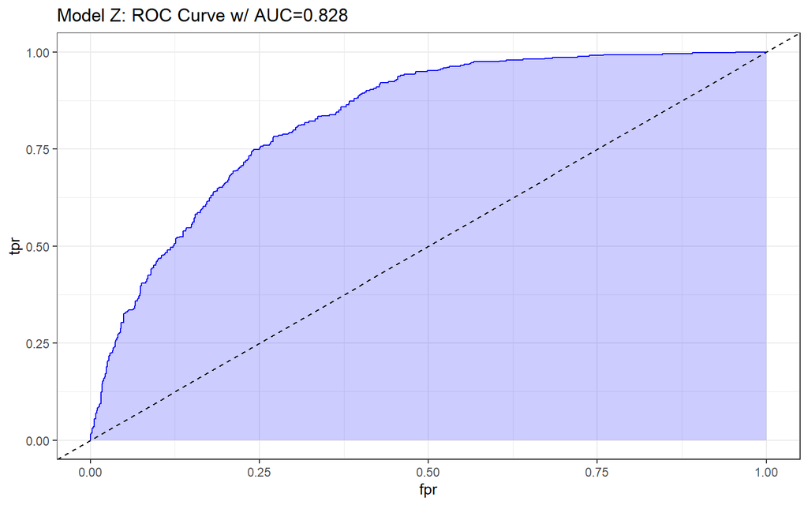

```r
prob = predict(model_z_lrm, type="fitted")
pred = prediction(prob, analysis_data$High_BP == "Yes")
perf = performance(pred, measure = "tpr", x.measure = "fpr")
auc = performance(pred, measure="auc")

auc = round(auc@y.values[[1]],3)
roc.data = data.frame(fpr=unlist(perf@x.values),
                       tpr = unlist(perf@y.values),
                       model="LRM")

ggplot(roc.data, aes(x = fpr, ymin = 0, ymax = tpr)) +
  geom_ribbon(alpha = 0.2, fill = "blue") +
  geom_line(aes(y = tpr), col = "blue") +
  geom_abline(intercept = 0, slope = 1, lty = "dashed") +
  labs(title = paste0("Model Z: ROC Curve w/ AUC=", auc))
```

The following code provides the ANOVA comparison table, which compares the augmented model **Model Z** to the main effects model **Model Y**:

```r
anova(model_z_glm, model_y_glm)
```

```
Analysis of Deviance Table

Model 1: High_BP == "Yes" ~ rcs(Systolic_BP, 5) + Potassium + Sodium +
    rcs(Age, 5) + Insomnia + Milk
Model 2: High_BP == "Yes" ~ Systolic_BP + Potassium + Sodium + Age + Insomnia +
    Milk
  Resid. Df Resid. Dev Df Deviance
1      1185     196.21
2      1191     197.95 -6  -1.7392
```

In order to generate a confusion matrix for **Model Z** just as was done with **Model Y**, **Model Z** will also need to be augmented as follows:

```r
model_z_aug = augment(model_z_glm, type.predict = "response")
```

With the `glm` variant of **Model Z** now augmented, the following provides the code necessary to produce the confusion matrix for **Model Z**:

```r
confuse_model_z = model_z_aug %>%
  mutate(High_BP_obs = factor(`High_BP == "Yes"` == "TRUE"),
         High_BP_pred = factor(.fitted >= 0.50),
         High_BP_obs = fct_relevel(High_BP_obs, "TRUE"),
         High_BP_pred = fct_relevel(High_BP_pred, "TRUE")) %$%
  table(High_BP_pred, High_BP_obs)
confuse_model_z
```

```
            High_BP_obs
High_BP_pred TRUE FALSE
       TRUE   272   139
       FALSE  161   628
```

From the confusion matrix above, we can see that for this model the specificity = 628/(628 + 139) = 0.819 = 81.9 %, the sensitivity = 272/(272 + 161) = 0.628 = 62.8 %, and the positive predictive value (i.e. precision) = 272/(272 + 139) = 0.662 = 66.2 %.

Recalling that the confusion matrix for **Model Y** demonstrated that the main effect model has a specificity = 81.7 %, a sensitivity = 60.5 %, and a positive predictive value (i.e. precision) = 65.2 %, we can see that **Model Z** performs slightly better on each of these metrics than **Model Y**.

Lastly, the following code generates an appropriate nomogram for **Model Z**:

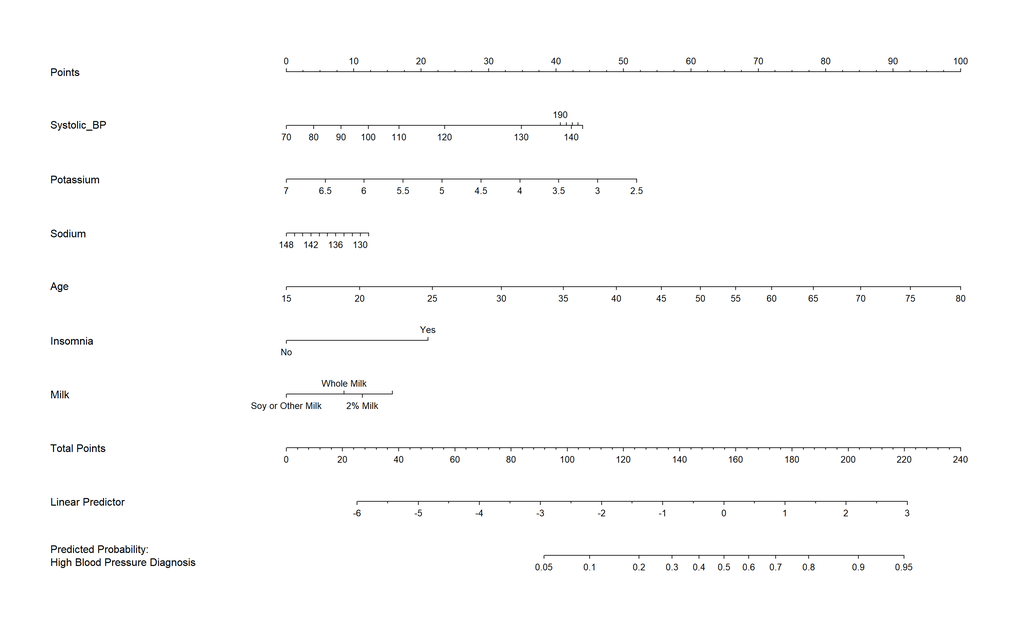

```r
plot(nomogram(model_z_lrm,
              fun = plogis,
              fun.at=c(0.05, seq(0.1, 0.9, by = 0.1), 0.95),
              funlabel = "Predicted Probability:\nHigh Blood Pressure Diagnosis"))
```

## 9.5 Validating the Models

Again, while both of these have already been provided above, the optimism-corrected Nagelkerke R-square statistics have been generated and provided below for comparison between the two models:

```r
set.seed(43202)
validate(model_y_lrm)
```

```
          index.orig training    test optimism index.corrected  n
Dxy           0.6441   0.6531  0.6401   0.0130          0.6311 40
R2            0.3840   0.3938  0.3776   0.0162          0.3679 40
Intercept     0.0000   0.0000 -0.0106   0.0106         -0.0106 40
Slope         1.0000   1.0000  0.9649   0.0351          0.9649 40
Emax          0.0000   0.0000  0.0096   0.0096          0.0096 40
D             0.3280   0.3382  0.3214   0.0168          0.3112 40
U            -0.0017  -0.0017  0.0005  -0.0021          0.0005 40
Q             0.3296   0.3398  0.3209   0.0189          0.3107 40
B             0.1644   0.1620  0.1658  -0.0039          0.1683 40
g             1.7265   1.7805  1.7065   0.0739          1.6525 40
gp            0.2989   0.3022  0.2962   0.0060          0.2929 40
```

```r
validate(model_z_lrm)
```

```
          index.orig training    test optimism index.corrected  n
Dxy           0.6470   0.6602  0.6390   0.0212          0.6258 40
R2            0.3917   0.4031  0.3783   0.0247          0.3670 40
Intercept     0.0000   0.0000 -0.0020   0.0020         -0.0020 40
Slope         1.0000   1.0000  0.9444   0.0556          0.9444 40
Emax          0.0000   0.0000  0.0131   0.0131          0.0131 40
D             0.3357   0.3471  0.3222   0.0249          0.3108 40
U            -0.0017  -0.0017  0.0014  -0.0031          0.0014 40
Q             0.3374   0.3488  0.3208   0.0280          0.3094 40
B             0.1635   0.1596  0.1659  -0.0063          0.1698 40
g             1.8155   1.8799  1.7628   0.1171          1.6984 40
gp            0.3016   0.3046  0.2960   0.0086          0.2930 40
```

## 9.6 Final Model

After reviewing both models above extensively, I would prefer **Model Y** over **Model Z**. As seen in the validation step above, while the difference between the optimism-corrected Nagelkerke R^2 values for the two models was relatively small, **Model Y**’s was slightly higher than **Model Z**’s. Following this trend, while the difference between the C statistics for both models was also very small, with **Model Y**’s = 0.5 + (Dxy/2) = 0.5 + (0.6311/2) = 0.816, and **Model Z**’s = 0.5 + (Dxy/2) = 0.5 + (0.6258/2) = 0.813, making **Model Y**’s C statistic slightly larger than **Model Z**’s, further justifying **Model Y** as the better of the two models, as the addition of the non-linear terms did not produce a better model based on these two metrics. That said, **Model Z** did produce better sensitivity, specificity, and positive predictive values than **Model Y** according to the results of their confusion matrices, and **Model Z** did produce a slightly better ROC curve than **Model Y**. However given the results of the validated optimism-corrected Nagelkerke R^2 and C statistics partnered with the complexities added by inclusion of the non-linear, such as their effects on the resultant nomorgram, I ultimately still prefer **Model Y** over **Model Z**.

The parameters for **Model Y**, along with the point estimates for the `glm` version of the model have been provided below:

```r
summary(model_y_glm)
```

```
Call:
fit.mult.impute(formula = High_BP == "Yes" ~ Systolic_BP + Potassium +
    Sodium + Age + Insomnia + Milk, fitter = glm, xtrans = log_mod_mimp,
    data = analysis_data, pr = FALSE, x = TRUE, y = TRUE)

Deviance Residuals:
     Min        1Q    Median        3Q       Max
-0.91353  -0.31918  -0.04576   0.36309   1.04735

Coefficients:
                        Estimate Std. Error t value Pr(>|t|)
(Intercept)            0.0592877  0.6103410   0.097  0.92263
Systolic_BP            0.0048018  0.0007206   6.663 4.08e-11 ***
Potassium             -0.0848670  0.0321152  -2.643  0.00834 **
Sodium                -0.0035333  0.0044010  -0.803  0.42223
Age                    0.0104013  0.0007593  13.699  < 2e-16 ***
InsomniaYes            0.1676069  0.0267631   6.263 5.28e-10 ***
Milk2% Milk            0.0219338  0.0275265   0.797  0.42571
Milk1% or Skim Milk    0.0500430  0.0374073   1.338  0.18122
MilkSoy or Other Milk -0.0586745  0.0386598  -1.518  0.12935
---
Signif. codes:  0 '***' 0.001 '**' 0.01 '*' 0.05 '.' 0.1 ' ' 1

(Dispersion parameter for gaussian family taken to be 0.1662016)

    Null deviance: 276.76  on 1199  degrees of freedom
Residual deviance: 197.95  on 1191  degrees of freedom
AIC: 1263

Number of Fisher Scoring iterations: 2
```

```r
tidy(model_y_glm, conf.int = 0.9) %>%
  select(term, estimate, std.error, p.value, conf.low, conf.high) %>%
  kable(digits = 3)
```

| term | estimate | std.error | p.value | conf.low | conf.high |
| --- | --- | --- | --- | --- | --- |
| (Intercept) | 0.059 | 0.610 | 0.923 | -1.018 | 1.373 |
| Systolic_BP | 0.005 | 0.001 | 0.000 | 0.003 | 0.006 |
| Potassium | -0.085 | 0.032 | 0.008 | -0.152 | -0.026 |
| Sodium | -0.004 | 0.004 | 0.422 | -0.013 | 0.004 |
| Age | 0.010 | 0.001 | 0.000 | 0.009 | 0.012 |
| InsomniaYes | 0.168 | 0.027 | 0.000 | 0.110 | 0.215 |
| Milk2% Milk | 0.022 | 0.028 | 0.426 | -0.024 | 0.084 |
| Milk1% or Skim Milk | 0.050 | 0.037 | 0.181 | -0.007 | 0.140 |
| MilkSoy or Other Milk | -0.059 | 0.039 | 0.129 | -0.132 | 0.019 |

Additionally, the parameters for **Model Y**, along with the odds ratio estimates for the `lrm` version of the model have been provided below:

```r
model_y_lrm
```

```
Logistic Regression Model

 fit.mult.impute(formula = High_BP == "Yes" ~ Systolic_BP + Potassium +
     Sodium + Age + Insomnia + Milk, fitter = lrm, xtrans = log_mod_mimp,
     data = analysis_data, pr = FALSE, x = TRUE, y = TRUE)

                        Model Likelihood    Discrimination    Rank Discrim.
                              Ratio Test           Indexes          Indexes
 Obs          1200    LR chi2     394.55    R2       0.384    C       0.823
  FALSE        767    d.f.             8    g        1.726    Dxy     0.647
  TRUE         433    Pr(> chi2) <0.0001    gr       5.622    gamma   0.647
 max |deriv| 2e-07                          gp       0.299    tau-a   0.299
                                            Brier    0.164

                        Coef    S.E.   Wald Z Pr(>|Z|)
 Intercept              -1.4588 3.9071 -0.37  0.7089
 Systolic_BP             0.0269 0.0047  5.73  <0.0001
 Potassium              -0.5500 0.1968 -2.79  0.0052
 Sodium                 -0.0264 0.0282 -0.94  0.3486
 Age                     0.0618 0.0053 11.74  <0.0001
 Insomnia=Yes            0.9575 0.1570  6.10  <0.0001
 Milk=2% Milk            0.1095 0.1837  0.60  0.5512
 Milk=1% or Skim Milk    0.3010 0.2581  1.17  0.2436
 Milk=Soy or Other Milk -0.4178 0.2736 -1.53  0.1267
```

```r
summary(model_y_lrm, conf.int = 0.9)
```

```
             Effects              Response : High_BP == "Yes"

 Factor                           Low   High  Diff. Effect   S.E.    Lower 0.9
 Systolic_BP                      110.0 134.0 24.0   0.64583 0.11272  0.46042
  Odds Ratio                      110.0 134.0 24.0   1.90760      NA  1.58470
 Potassium                          3.8   4.3  0.5  -0.27498 0.09839 -0.43681
  Odds Ratio                        3.8   4.3  0.5   0.75959      NA  0.64609
 Sodium                           138.0 142.0  4.0  -0.10558 0.11263 -0.29085
  Odds Ratio                      138.0 142.0  4.0   0.89980      NA  0.74763
 Age                               33.0  62.0 29.0   1.79110 0.15255  1.54010
  Odds Ratio                       33.0  62.0 29.0   5.99580      NA  4.66520
 Insomnia - Yes:No                  1.0   2.0   NA   0.95752 0.15703  0.69922
  Odds Ratio                        1.0   2.0   NA   2.60520      NA  2.01220
 Milk - Whole Milk:2% Milk          2.0   1.0   NA  -0.10947 0.18370 -0.41162
  Odds Ratio                        2.0   1.0   NA   0.89631      NA  0.66258
 Milk - 1% or Skim Milk:2% Milk     2.0   3.0   NA   0.19152 0.25279 -0.22429
  Odds Ratio                        2.0   3.0   NA   1.21110      NA  0.79909
 Milk - Soy or Other Milk:2% Milk   2.0   4.0   NA  -0.52729 0.27120 -0.97337
  Odds Ratio                        2.0   4.0   NA   0.59020      NA  0.37781
 Upper 0.9
  0.831230
  2.296100
 -0.113140
  0.893030
  0.079683
  1.082900
  2.042000
  7.705800
  1.215800
  3.373000
  0.192690
  1.212500
  0.607320
  1.835500
 -0.081218
  0.921990
```

These effect sizes have been plotted below to demonstrate them visually:

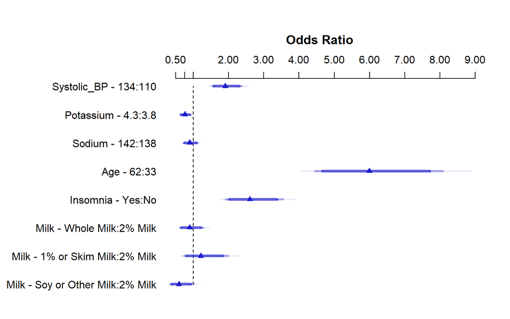

```r
par(mar=c(2, 4, 4, 2) + 0.1)
plot(summary(model_y_lrm))
```

As was shown when producing **Model Y** above, the following provides the necessary code to generate the ROC curve plot for the `lrm` version of **Model Y**:

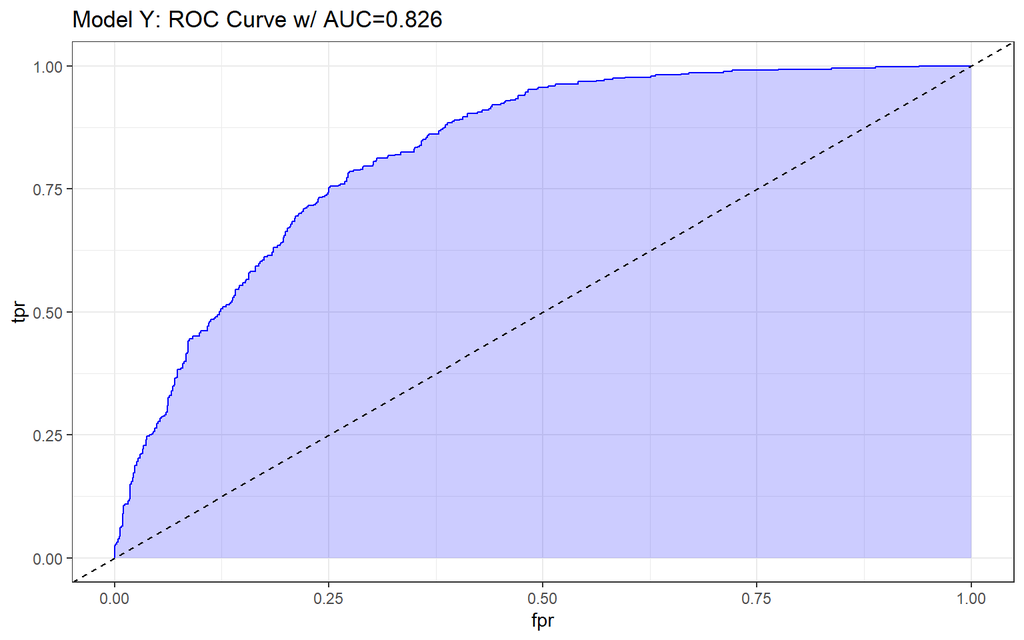

```r
prob = predict(model_y_lrm, type="fitted")
pred = prediction(prob, analysis_data$High_BP == "Yes")
perf = performance(pred, measure = "tpr", x.measure = "fpr")
auc = performance(pred, measure="auc")

auc = round(auc@y.values[[1]],3)
roc.data = data.frame(fpr=unlist(perf@x.values),
                       tpr = unlist(perf@y.values),
                       model="LRM")

ggplot(roc.data, aes(x = fpr, ymin = 0, ymax = tpr)) +
  geom_ribbon(alpha = 0.2, fill = "blue") +
  geom_line(aes(y = tpr), col = "blue") +
  geom_abline(intercept = 0, slope = 1, lty = "dashed") +
  labs(title = paste0("Model Y: ROC Curve w/ AUC=", auc))
```

```r
set.seed(43202)
validate(model_a_ols)
```

[output not shown]

Lastly, the nomogram for **Model Y** has once again been provided below:

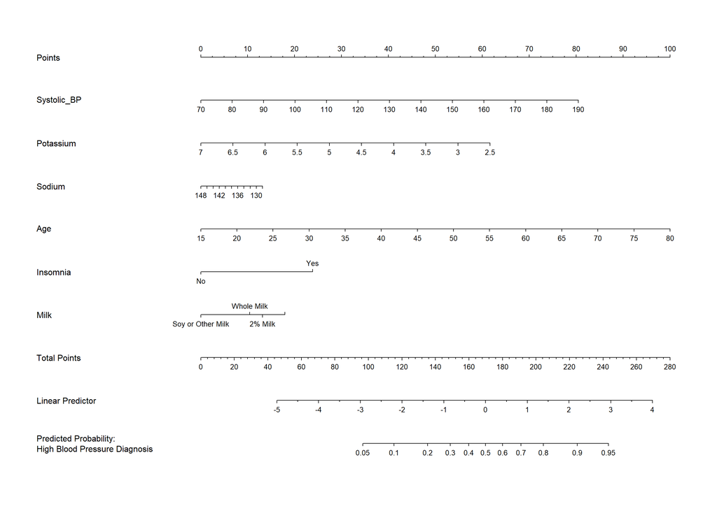

```r
plot(nomogram(model_y_lrm,
              fun = plogis,
              fun.at=c(0.05, seq(0.1, 0.9, by = 0.1), 0.95),
              funlabel = "Predicted Probability:\nHigh Blood Pressure Diagnosis"))
```

To clarify how this nomogram is meant to be interpreted, lets take the following two theoretical subjects, named James and Lauren. Both James and Lauren have a sodium level of 132, a potassium level of 6, have a systolic blood pressure of 130, do not have insomnia, and drink 1% or skim milk, but James is 30 and Lauren is 40. As such James would have an approximate total number of 102.5 points on the nomogram, which correlates to an approximate predicted probability of having been diagnosed with high blood pressure in the past of about 0.05, or or 5% predicted probability, whereas Lauren would have an approximate total number of 117.5 points on the nomogram, which correlates to an approximate predicted probability of having been diagnosed with high blood pressure in the past of about 0.1, or or 10% predicted probability.

# 10 Discussion

Before beginning either of my regression analyses, I stated that I hoped to be able to answer the following two question by the time I was done:

- Can an adult’s systolic blood pressure be effectively predicted as a function of their sodium levels, potassium levels, age, milk consumption type, whether they have a past high blood pressure diagnosis, and their insomnia disclosure, via a linear regression model?
- Can a previous high blood pressure clinical diagnoses be effectively predicted as a function of a subject’s age, sodium levels, potassium levels, current systolic blood pressure, insomnia disclosure, and their main milk consumption type via a logistic regression model?

The results of my linear regression analyses illustrated that I could develop a model based off of this data, however given how poorly the models performed in the various summary statistics I would say that it would not be accurate to state that I could do so effectively with this data. The logistic regression models designed to predicted prior high blood pressure clinical diagnosis by comparison performed a little better than the linear regression models for systolic blood pressure, however it also still leaves some room for improvement with some of the selected predictors, so I hesitate to state that they can effectively predict previous high blood pressure diagnosis at this time either.

Now that this project is complete, I’d have to say that I found a number of steps in this process far more difficult than I had anticipated. I think the process I had far more difficulty with than the rest was addressing the missing data via imputation - I learned through this process that there are far more methods than I would have anticipated to impute data, and I struggled to properly discern which methods would be the most appropriate for the data I was working with. Additionally I also didn’t realize until far later in the regression analyses that we were specifically instructed to filter out cases with missing outcomes in this project, which contributed to this confusion, and greatly extended the amount of time I needed to complete the analyses. Until I realized this I wasn’t certain which method I should ultimately choose to impute the data, as some methods would impute data that would ultimately suggest a logarithmic transformation for the outcome data and others would suggest an inverse transformation outcome for the data, and ultimately led to me reworking my regression analyses a multitude of times. Looking back now, I wish that I had understood just how involved these analyses would be when I began this project, as I would have allocated even more uninterrupted time to work on it than I already had (which I had already taken several days off the past couple weeks to focus solely on it), and I certainly would have reached out with far more questions a lot sooner.

That said, I did gain an extensive amount of insight and learned a great deal regarding these types of regression analyses that I did not realize before beginning this project, and while I’m not certain that this is the most important one of them, one important one was definitely regarding the proper interpretation of nomograms. While we discussed them in class, and I understood the general premise of them, I did struggle for a bit to determine how to properly produce one that included a back transformation for the predicted outcome probability when using an outcome transformation other than a log transformation. I also had a lot of difficulty actually selecting my data initially, as the open-ended-ness of the data selection process, while liberating, also made it challenging to identify data that I thought would actually work appropriately for this project. I think ultimately though that what contributed to the difficulty the most for this project was that I was working on it alone. The sheer volume of what’s required of us to complete the project lends itself to group work far better, provided both individuals are invested in completing the project and are willing to work together on it, and due to the beginning of the semester starting online, I was unable to successfully find a partner to work with. Nevertheless, I think I ultimately learned far more as a result, and despite the challenges I faced I really did enjoy working on this project.

# 11 Affirmation

I am certain that it is completely appropriate for these data to be shared with anyone, without any conditions. There are no concerns about privacy or security.

# 12 References

[1. National Health and Nutrition Examination Survey, 2017 - 2018 Data Files](https://wwwn.cdc.gov/nchs/nhanes/continuousnhanes/default.aspx?BeginYear=2017)

[2. Zhang Z. Missing data imputation: focusing on single imputation. Ann Transl Med. 2016 Jan;4(1):9. doi: 10.3978/j.issn.2305-5839.2015.12.38. PMID: 26855945; PMCID: PMC4716933.](https://www.ncbi.nlm.nih.gov/pmc/articles/PMC4716933/)